# Análisis de variables alternativas de crecimiento mediante un modelo de regresión lineal múltiple

Observemos, solo por curiosidad, si quitamos el parámetro `lm` en `geom_smooth()` si es posible que las variables tengan un comportamiento diferente al lineal:

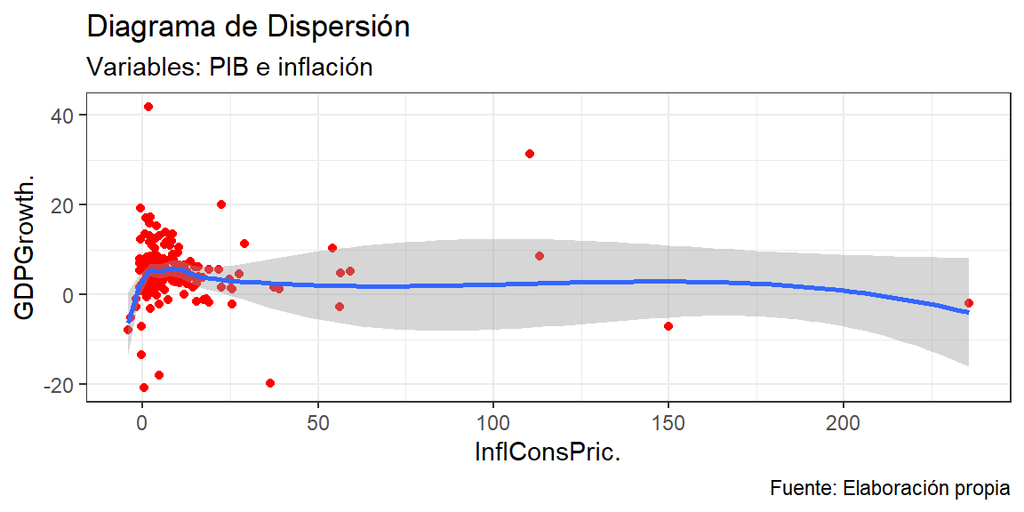

```r
# Diagrama de dispersión
ggplot(data=datosCrecimiento2021,aes(x=InflConsPric.,y=GDPGrowth.))+
  geom_point(col="red") +
  geom_smooth()+
  labs(title="Diagrama de Dispersión",
       subtitle = "Variables: PIB e inflación",
       caption="Fuente: Elaboración propia")+
  theme_bw()
```

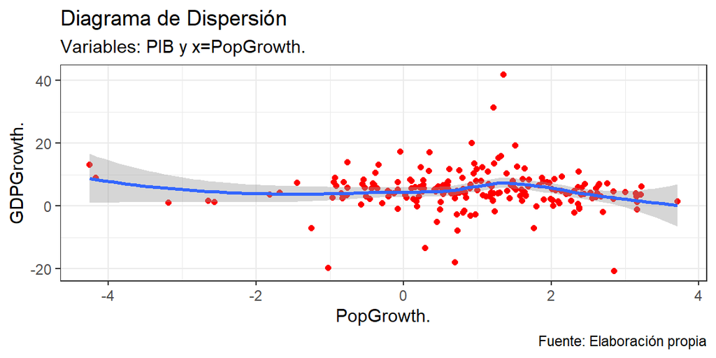

```r
ggplot(data=datosCrecimiento2021,aes(x=PopGrowth.,y=GDPGrowth.))+
  geom_point(col="red") +
  geom_smooth()+
  labs(title="Diagrama de Dispersión",
       subtitle = "Variables: PIB y x=PopGrowth.",
       caption="Fuente: Elaboración propia")+
  theme_bw()
```

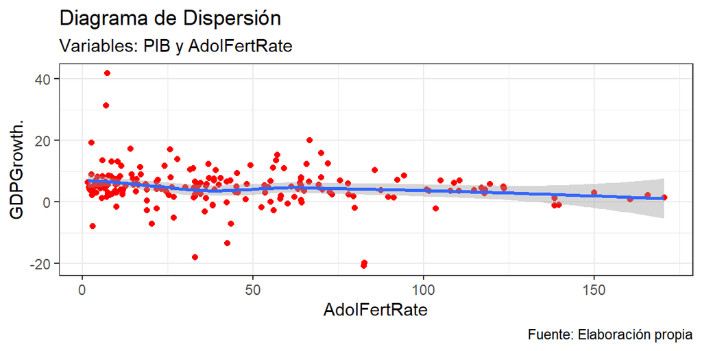

```r
ggplot(data=datosCrecimiento2021,aes(x=AdolFertRate,y=GDPGrowth.))+
  geom_point(col="red") +
  geom_smooth()+
  labs(title="Diagrama de Dispersión",
       subtitle = "Variables: PIB y AdolFertRate",
       caption="Fuente: Elaboración propia")+
  theme_bw()
```

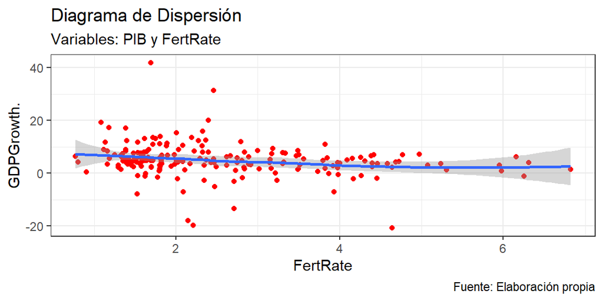

```r
ggplot(data=datosCrecimiento2021,aes(x=FertRate,y=GDPGrowth.))+
  geom_point(col="red") +
  geom_smooth()+
  labs(title="Diagrama de Dispersión",
       subtitle = "Variables: PIB y FertRate",
       caption="Fuente: Elaboración propia")+
  theme_bw()
```

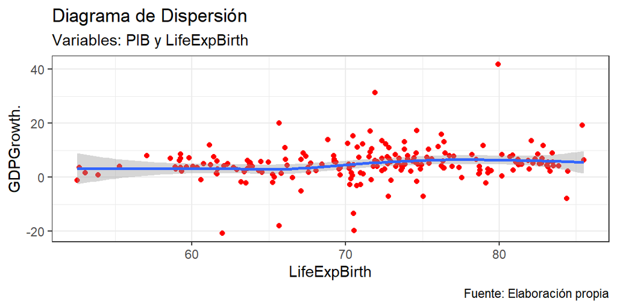

```r
ggplot(data=datosCrecimiento2021,aes(x=LifeExpBirth,y=GDPGrowth.))+
  geom_point(col="red") +
  geom_smooth()+
  labs(title="Diagrama de Dispersión",
       subtitle = "Variables: PIB y LifeExpBirth",
       caption="Fuente: Elaboración propia")+
  theme_bw()
```

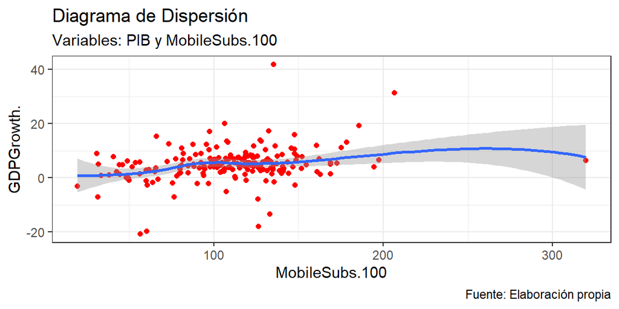

```r
ggplot(data=datosCrecimiento2021,aes(x=MobileSubs.100,y=GDPGrowth.))+
  geom_point(col="red") +
  geom_smooth()+
  labs(title="Diagrama de Dispersión",
       subtitle = "Variables: PIB y MobileSubs.100",
       caption="Fuente: Elaboración propia")+
  theme_bw()
```

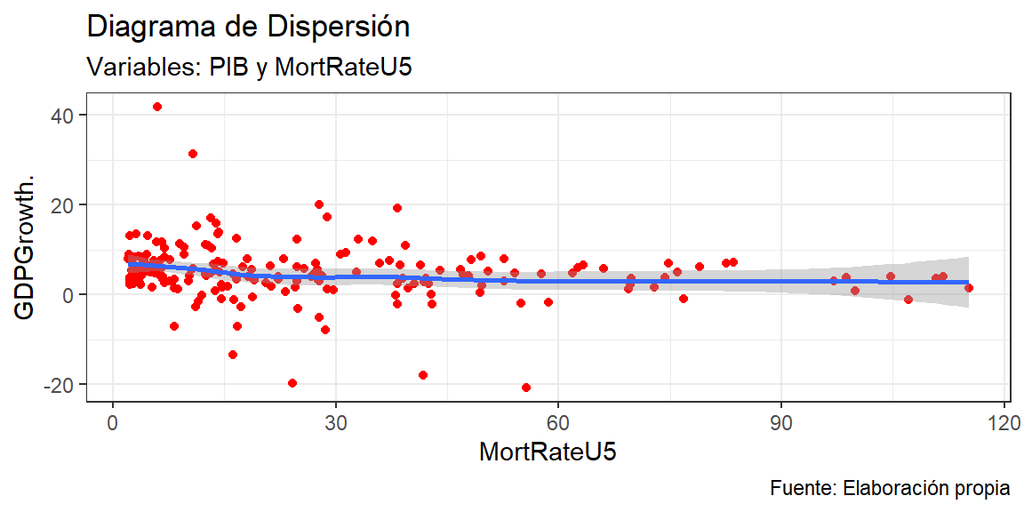

```r
ggplot(data=datosCrecimiento2021,aes(x=MortRateU5,y=GDPGrowth.))+
  geom_point(col="red") +
  geom_smooth()+
  labs(title="Diagrama de Dispersión",
       subtitle = "Variables: PIB y MortRateU5",
       caption="Fuente: Elaboración propia")+
  theme_bw()
```

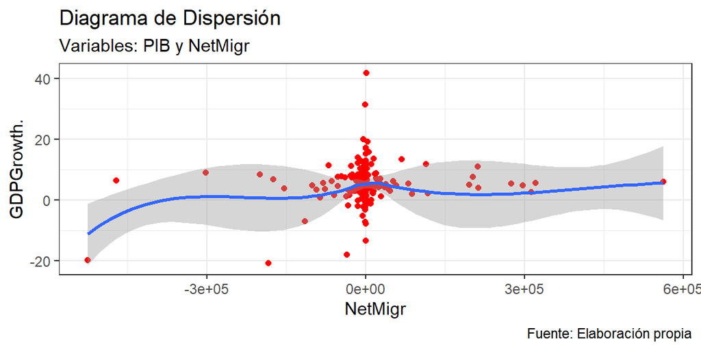

```r
ggplot(data=datosCrecimiento2021,aes(x=NetMigr,y=GDPGrowth.))+
  geom_point(col="red") +
  geom_smooth()+
  labs(title="Diagrama de Dispersión",
       subtitle = "Variables: PIB y NetMigr",
       caption="Fuente: Elaboración propia")+
  theme_bw()
```

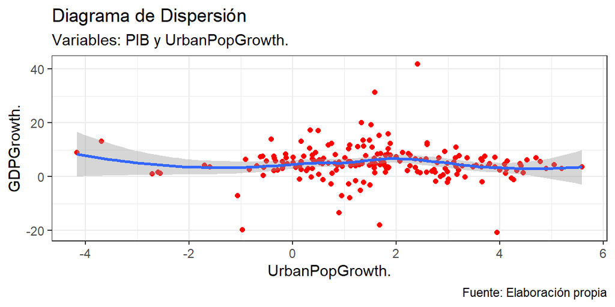

```r
ggplot(data=datosCrecimiento2021,aes(x=UrbanPopGrowth.,y=GDPGrowth.))+
  geom_point(col="red") +
  geom_smooth()+
  labs(title="Diagrama de Dispersión",
       subtitle = "Variables: PIB y UrbanPopGrowth.",
       caption="Fuente: Elaboración propia")+
  theme_bw()
```

# Modelo teórico y Modelo estadístico

Nuestro modelo teórico es el siguiente:

CrecimientoEconomico = f (CrecimientoPoblacion, Inflacion, EsperanzaVidaNacer, SuscripcionesTelefonosCelulares, MortalidadNinosMenores5Anos, MigracionNeta, CrecimientoPoblacionUrbana)

El modelo estadístico es el siguiente:

Yi =β<sub>0</sub> +β<sub>1</sub>Xi1 +β<sub>2</sub>Xi2 + β<sub>3</sub>Xi3 + β<sub>4</sub>Xi4 +β<sub>5</sub>Xt5 +β<sub>6</sub>Xi6 + β<sub>7</sub>Xi7 + β<sub>8</sub>Xi8 + + β<sub>9</sub>Xi9 + ui

En este modelo Xi1 se refiere al crecimiento de la población, Xi2 a la tasa de fertilidad en adolescentes, Xi3 a la tasa de fertilidad, Xi4 a la inflación, Xi5 a la esperanza de vida, Xi6 a las suscripciones de teléfonos celulares, Xi7 a la tasa de mortalidad en niños menores a 5 años, Xi8 a la migración neta y Xi9 al crecimiento de la población urbana.

# Estimación del modelo de regresión mediante mínimos cuadrados ordinarios

```r
# Regresión Lineal Múltiple
n<-length(PopGrowth.)
k<-9
reg1<-lm(GDPGrowth.~PopGrowth.+AdolFertRate+FertRate+InflConsPric.+LifeExpBirth+MobileSubs.100+MortRateU5+NetMigr+UrbanPopGrowth.,data=datosCrecimiento2021)
summary(reg1)
```

```
##
## Call:
## lm(formula = GDPGrowth. ~ PopGrowth. + AdolFertRate + FertRate +
##     InflConsPric. + LifeExpBirth + MobileSubs.100 + MortRateU5 +
##     NetMigr + UrbanPopGrowth., data = datosCrecimiento2021)
##
## Residuals:
##     Min      1Q  Median      3Q     Max
## -24.109  -2.813  -0.223   2.330  33.647
##
## Coefficients:
##                   Estimate Std. Error t value Pr(>|t|)
## (Intercept)      6.593e+00  9.385e+00   0.703   0.4832
## PopGrowth.       1.453e-02  1.145e+00   0.013   0.9899
## AdolFertRate    -5.206e-03  2.308e-02  -0.226   0.8218
## FertRate        -1.538e+00  8.167e-01  -1.884   0.0611 .
## InflConsPric.   -8.534e-04  1.835e-02  -0.047   0.9630
## LifeExpBirth    -4.189e-02  1.119e-01  -0.374   0.7085
## MobileSubs.100   3.612e-02  1.318e-02   2.742   0.0067 **
## MortRateU5      -7.595e-03  3.371e-02  -0.225   0.8220
## NetMigr          6.772e-06  4.782e-06   1.416   0.1584
## UrbanPopGrowth.  1.086e+00  9.335e-01   1.164   0.2460
## ---
## Signif. codes:  0 '***' 0.001 '**' 0.01 '*' 0.05 '.' 0.1 ' ' 1
##
## Residual standard error: 6.008 on 191 degrees of freedom
## Multiple R-squared:  0.1333, Adjusted R-squared:  0.09241
## F-statistic: 3.263 on 9 and 191 DF,  p-value: 0.001028
```

```r
stargazer(reg1,type="text")
```

```
##
## ===============================================
##                         Dependent variable:
##                     ---------------------------
##                             GDPGrowth.
## -----------------------------------------------
## PopGrowth.                     0.015
##                               (1.145)
##
## AdolFertRate                  -0.005
##                               (0.023)
##
## FertRate                      -1.538*
##                               (0.817)
##
## InflConsPric.                 -0.001
##                               (0.018)
##
## LifeExpBirth                  -0.042
##                               (0.112)
##
## MobileSubs.100               0.036***
##                               (0.013)
##
## MortRateU5                    -0.008
##                               (0.034)
##
## NetMigr                       0.00001
##                              (0.00000)
##
## UrbanPopGrowth.                1.086
##                               (0.934)
##
## Constant                       6.593
##                               (9.385)
##
## -----------------------------------------------
## Observations                    201
## R2                             0.133
## Adjusted R2                    0.092
## Residual Std. Error      6.008 (df = 191)
## F Statistic           3.263*** (df = 9; 191)
## ===============================================
## Note:               *p<0.1; **p<0.05; ***p<0.01
```

A través del método de mínimos cuadrados ordinarios construimos un modelo de regresión lineal múltiple. Esto explica de qué manera y a qué grado se relacionan nuestras variables independientes con el crecimiento económico. Los resultados fueron los siguientes: por un lado, las suscripciones de teléfono celular resultaron ser la única variable significativa y la tasa de fertilidad es marginalmente significativa; por otro lado, la R² fue igual a 0.1333 y la R² ajustada fue igual a 0.09241. En pocas palabras, los resultados de esta regresión no eran los que esperábamos, pues la mayoría de estas variables no son significativas y los valores de la R² y R² ajustada fueron muy pequeños.

A primera vista, este modelo no es muy bueno para estimar cambios en el crecimiento económico y , por lo tanto, debe ser corregido. No obstante, antes de realizar cualquier corrección, hay que calcular la significancia individual y conjunta de las variables independientes, verificar el resto de supuestos, etc.

```r
ygorro<-reg1$fitted.values
ugorro<-reg1$residuals
sigma2<-sum(ugorro^2)/(n-k-1)
```

Definimos ygorro: valores estimados, ugorro: errores estimados, sigma2: varianza de los residuales.

Ahora vamos a probar la significancia individual de cada variable.

```r
# Pruebas de significancia (individual)
linearHypothesis(reg1,"PopGrowth.=0")
```

```
## Linear hypothesis test
##
## Hypothesis:
## PopGrowth. = 0
##
## Model 1: restricted model
## Model 2: GDPGrowth. ~ PopGrowth. + AdolFertRate + FertRate + InflConsPric. +
##     LifeExpBirth + MobileSubs.100 + MortRateU5 + NetMigr + UrbanPopGrowth.
##
##   Res.Df  RSS Df Sum of Sq     F Pr(>F)
## 1    192 6895
## 2    191 6895  1 0.0058142 2e-04 0.9899
```

```r
linearHypothesis(reg1,"AdolFertRate=0")
```

```
## Linear hypothesis test
##
## Hypothesis:
## AdolFertRate = 0
##
## Model 1: restricted model
## Model 2: GDPGrowth. ~ PopGrowth. + AdolFertRate + FertRate + InflConsPric. +
##     LifeExpBirth + MobileSubs.100 + MortRateU5 + NetMigr + UrbanPopGrowth.
##
##   Res.Df    RSS Df Sum of Sq      F Pr(>F)
## 1    192 6896.9
## 2    191 6895.0  1     1.837 0.0509 0.8218
```

```r
linearHypothesis(reg1,"FertRate=0")
```

```
## Linear hypothesis test
##
## Hypothesis:
## FertRate = 0
##
## Model 1: restricted model
## Model 2: GDPGrowth. ~ PopGrowth. + AdolFertRate + FertRate + InflConsPric. +
##     LifeExpBirth + MobileSubs.100 + MortRateU5 + NetMigr + UrbanPopGrowth.
##
##   Res.Df    RSS Df Sum of Sq      F  Pr(>F)
## 1    192 7023.1
## 2    191 6895.0  1    128.07 3.5478 0.06114 .
## ---
## Signif. codes:  0 '***' 0.001 '**' 0.01 '*' 0.05 '.' 0.1 ' ' 1
```

```r
linearHypothesis(reg1,"InflConsPric.=0")
```

```
## Linear hypothesis test
##
## Hypothesis:
## InflConsPric. = 0
##
## Model 1: restricted model
## Model 2: GDPGrowth. ~ PopGrowth. + AdolFertRate + FertRate + InflConsPric. +
##     LifeExpBirth + MobileSubs.100 + MortRateU5 + NetMigr + UrbanPopGrowth.
##
##   Res.Df    RSS Df Sum of Sq      F Pr(>F)
## 1    192 6895.1
## 2    191 6895.0  1  0.078076 0.0022  0.963
```

```r
linearHypothesis(reg1,"LifeExpBirth=0")
```

```
## Linear hypothesis test
##
## Hypothesis:
## LifeExpBirth = 0
##
## Model 1: restricted model
## Model 2: GDPGrowth. ~ PopGrowth. + AdolFertRate + FertRate + InflConsPric. +
##     LifeExpBirth + MobileSubs.100 + MortRateU5 + NetMigr + UrbanPopGrowth.
##
##   Res.Df    RSS Df Sum of Sq      F Pr(>F)
## 1    192 6900.1
## 2    191 6895.0  1    5.0615 0.1402 0.7085
```

```r
linearHypothesis(reg1,"MobileSubs.100=0")
```

```
## Linear hypothesis test
##
## Hypothesis:
## MobileSubs.100 = 0
##
## Model 1: restricted model
## Model 2: GDPGrowth. ~ PopGrowth. + AdolFertRate + FertRate + InflConsPric. +
##     LifeExpBirth + MobileSubs.100 + MortRateU5 + NetMigr + UrbanPopGrowth.
##
##   Res.Df    RSS Df Sum of Sq      F   Pr(>F)
## 1    192 7166.4
## 2    191 6895.0  1    271.32 7.5159 0.006697 **
## ---
## Signif. codes:  0 '***' 0.001 '**' 0.01 '*' 0.05 '.' 0.1 ' ' 1
```

```r
linearHypothesis(reg1,"MortRateU5=0")
```

```
## Linear hypothesis test
##
## Hypothesis:
## MortRateU5 = 0
##
## Model 1: restricted model
## Model 2: GDPGrowth. ~ PopGrowth. + AdolFertRate + FertRate + InflConsPric. +
##     LifeExpBirth + MobileSubs.100 + MortRateU5 + NetMigr + UrbanPopGrowth.
##
##   Res.Df    RSS Df Sum of Sq      F Pr(>F)
## 1    192 6896.9
## 2    191 6895.0  1    1.8327 0.0508  0.822
```

```r
linearHypothesis(reg1,"UrbanPopGrowth.=0")
```

```
## Linear hypothesis test
##
## Hypothesis:
## UrbanPopGrowth. = 0
##
## Model 1: restricted model
## Model 2: GDPGrowth. ~ PopGrowth. + AdolFertRate + FertRate + InflConsPric. +
##     LifeExpBirth + MobileSubs.100 + MortRateU5 + NetMigr + UrbanPopGrowth.
##
##   Res.Df    RSS Df Sum of Sq      F Pr(>F)
## 1    192 6943.9
## 2    191 6895.0  1    48.892 1.3543  0.246
```

Ahora vamos a probar la significancia individual de cada variable. En esta prueba confirmamos lo que anteriormente habíamos observado. Primero, el crecimiento de la población, la tasa de fertilidad en adolescentes, la inflación, la esperanza de vida, la tasa de mortalidad en niños menores a cinco años y el crecimiento de la población no son variables significativas. Esto se debe a que el valor p de cada una de estas variables es mayor a 0.01. Segundo, la tasa de fertilidad es ligeramente significativa, pues su valor p se encuentra entre los parámetros 0.05 y 0.1. Por último, la única variable significativa son las suscripciones de teléfono celular. Su valor p fue igual a 0.006697.

```r
# Prueba de significancia (conjunta)
linearHypothesis(reg1,c("PopGrowth.=0", "InflConsPric.=0","FertRate=0","LifeExpBirth=0","AdolFertRate=0","MobileSubs.100=0", "MortRateU5=0","NetMigr=0","UrbanPopGrowth.=0"))
```

```
## Linear hypothesis test
##
## Hypothesis:
## PopGrowth. = 0
## InflConsPric. = 0
## FertRate = 0
## LifeExpBirth = 0
## AdolFertRate = 0
## MobileSubs.100 = 0
## MortRateU5 = 0
## NetMigr = 0
## UrbanPopGrowth. = 0
##
## Model 1: restricted model
## Model 2: GDPGrowth. ~ PopGrowth. + AdolFertRate + FertRate + InflConsPric. +
##     LifeExpBirth + MobileSubs.100 + MortRateU5 + NetMigr + UrbanPopGrowth.
##
##   Res.Df    RSS Df Sum of Sq      F   Pr(>F)
## 1    200 7955.1
## 2    191 6895.0  9      1060 3.2626 0.001028 **
## ---
## Signif. codes:  0 '***' 0.001 '**' 0.01 '*' 0.05 '.' 0.1 ' ' 1
```

Para continuar con el análisis, aplicaremos la función anova(). Esta se utiliza para realizar análisis de la varianza en modelos lineales.

```r
anova(reg1)
```

```
## Analysis of Variance Table
##
## Response: GDPGrowth.
##                  Df Sum Sq Mean Sq F value   Pr(>F)
## PopGrowth.        1   17.2  17.235  0.4774 0.490432
## AdolFertRate      1  315.0 315.047  8.7271 0.003529 **
## FertRate          1  316.0 316.026  8.7543 0.003479 **
## InflConsPric.     1    0.7   0.661  0.0183 0.892490
## LifeExpBirth      1    4.9   4.926  0.1364 0.712251
## MobileSubs.100    1  287.3 287.347  7.9598 0.005288 **
## MortRateU5        1    2.7   2.747  0.0761 0.782972
## NetMigr           1   67.1  67.138  1.8598 0.174254
## UrbanPopGrowth.   1   48.9  48.892  1.3543 0.245971
## Residuals       191 6895.0  36.100
## ---
## Signif. codes:  0 '***' 0.001 '**' 0.01 '*' 0.05 '.' 0.1 ' ' 1
```

Podemos observar una tabla que presenta datos para cada variable sobre los grados de libertad, la suma de cuadrados, la media de cuadrados, el valor F y el valor P. En cuanto a la suma de cuadrados de cada variable, sabemos que entre mayor sea el valor de esta columna mayor será la variabilidad explicada por cada variable independiente. Cabe destacar que en esta columna también se presentan datos sobre los residuales del modelo. De esta manera, podemos inferir que la variabilidad que no se explica por ninguna variable independiente es mayor a la variabilidad explicada por cualquier variable del modelo.

La siguiente columna (media de cuadrados) brinda información de la variabilidad promedio que se le puede atribuir a cada variable independiente. Es interesante observar que ahora la variabilidad promedio atribuida a la tasa de fertilidad en adolescentes, tasa de fertilidad y suscripciones de teléfonos celulares es mayor a la media de cuadrados de los residuales. Por último, debido al valor F y al valor P, podemos observar nuevamente la significancia de cada variable del modelo. Las interpretaciones de esto se pueden encontrar en las secciones anteriores con las pruebas de significancia conjunta e individual.

A continuación, haremos dos intervalos de confianza para cada variable del modelo. El primero consiste en un intervalo de confianza al 95 % y el segundo en un intervalo de confianza al 90%.

```r
# Intervalos de confianza
confint(reg1)
```

```
##                         2.5 %       97.5 %
## (Intercept)     -1.191847e+01 2.510447e+01
## PopGrowth.      -2.243312e+00 2.272366e+00
## AdolFertRate    -5.073082e-02 4.031797e-02
## FertRate        -3.149332e+00 7.261357e-02
## InflConsPric.   -3.705036e-02 3.534349e-02
## LifeExpBirth    -2.625663e-01 1.787826e-01
## MobileSubs.100   1.013338e-02 6.211333e-02
## MortRateU5      -7.408313e-02 5.889319e-02
## NetMigr         -2.660424e-06 1.620433e-05
## UrbanPopGrowth. -7.549263e-01 2.927697e+00
```

```r
confint(reg1,level=0.90)
```

```
##                           5 %          95 %
## (Intercept)     -8.919117e+00  2.210512e+01
## PopGrowth.      -1.877482e+00  1.906536e+00
## AdolFertRate    -4.335465e-02  3.294181e-02
## FertRate        -2.888311e+00 -1.884069e-01
## InflConsPric.   -3.118549e-02  2.947862e-02
## LifeExpBirth    -2.268112e-01  1.430274e-01
## MobileSubs.100   1.434444e-02  5.790226e-02
## MortRateU5      -6.331027e-02  4.812034e-02
## NetMigr         -1.132128e-06  1.467603e-05
## UrbanPopGrowth. -4.565847e-01  2.629356e+00
```

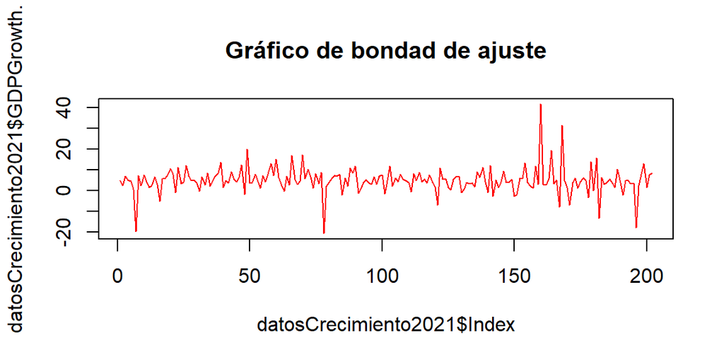

```r
# Gráfico de bondad de ajuste
plot(datosCrecimiento2021$Index,datosCrecimiento2021$GDPGrowth.,type="l",
     col="red",
     main="Gráfico de bondad de ajuste")
```

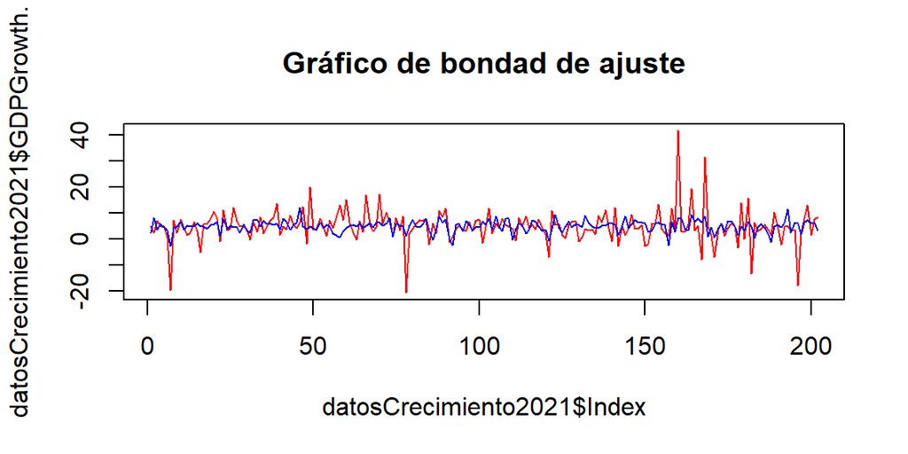

```r
plot(datosCrecimiento2021$Index,datosCrecimiento2021$GDPGrowth.,type="l",
     col="red",
     main="Gráfico de bondad de ajuste")
lines(datosCrecimiento2021$Index,ygorro,type="l",col="blue")
```

Finalmente realizaremos el gráfico de residuales En este observamos que no hay patrones en los residuales, lo que significa que no hay autocorrelación. De igual manera, podemos decir que no hay heterocedasticidad, pues los residuales se distribuyen de una manera homogénea.

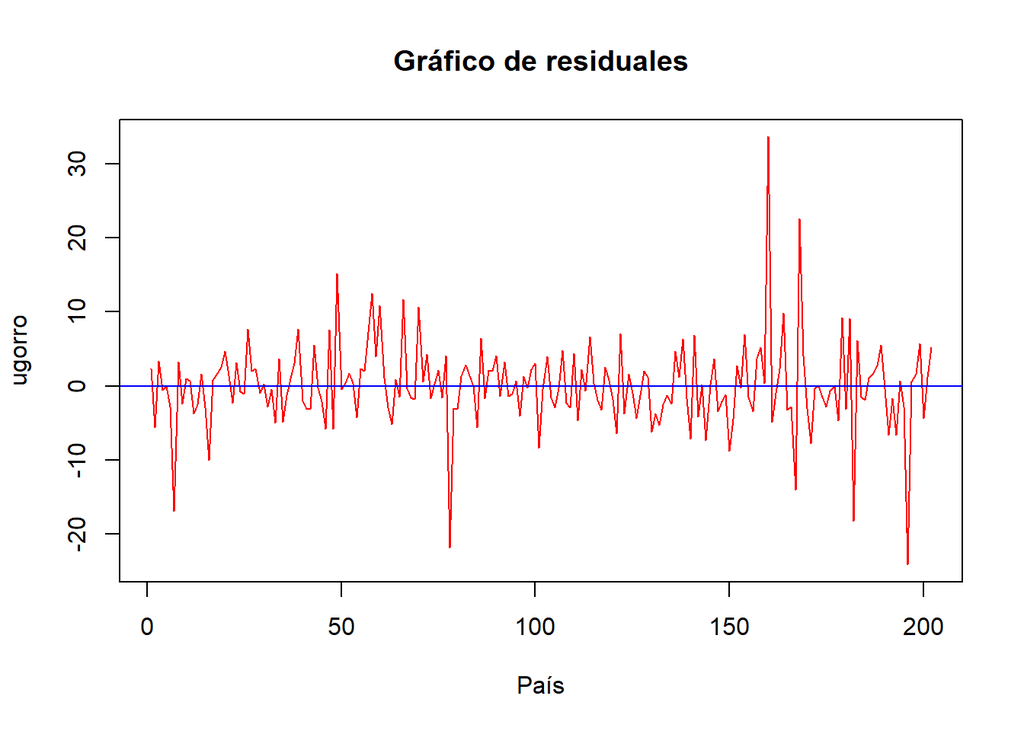

```r
# Gráfico de residuales
plot(datosCrecimiento2021$Index,ugorro,type="l",
     col="red",
     main="Gráfico de residuales",
     xlab = "País")
abline(h=0, col="blue")
```

# **Verificación de los supuestos**

## **Verificación de Normalidad**

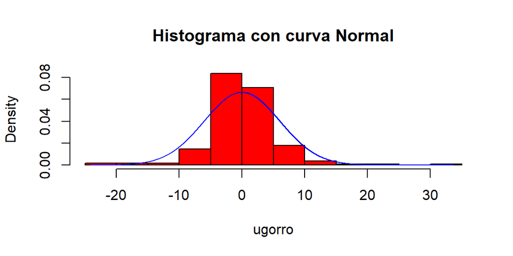

```r
hist(ugorro,breaks=10,col="red",freq = F,
     main="Histograma con curva Normal")
dz<-seq(min(ugorro), max(ugorro), 0.001)
lines(dnorm(dz,0,sqrt(sigma2))~dz, type="l",
      col="blue", lwd=1)
```

Si bien el histograma no nos sugiere que la distribución de nuestros residuales es normal, es importante mencionar que no presenta ningún sesgo. El gráfico debería de parecerse lo más posible a la curva de la distribución normal, pero aquí podemos observar que en el intervalo de [-5,5] hay frecuencia de más. Por otro lado, los intervalos de [-15, -5] y [5, 15] tienen una frecuencia menor a la esperada.

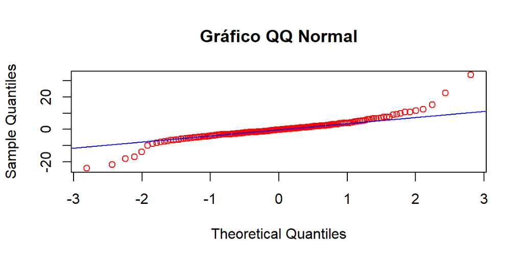

```r
qqnorm(ugorro,col="red",main="Gráfico QQ Normal")
qqline(ugorro,col="blue")
```

Este gráfico nos muestra que la mayoría de nuestros residuales se encuentran sobre la línea azul de 45 grados; sin embargo, podemos observar claramente la presencia de datos atípicos en los extremos. Los intervalos de [-3, -2] y [1.8, 3] son aquellos en los que se muestran estos outliers. Todos los puntos deberían de pertenecer a un mismo rango.

**Prueba Jarque-Bera**

Esta prueba claramente nos indica que la distribución de nuestro término estocástico no es normal. El valor p es considerablemente menor que mi alpha, el nivel de significancia. De este modo, se rechaza la hipótesis nula, la cual nos indica que la distribución es normal.

```r
jarque.bera.test(ugorro)
```

```
##
##  Jarque Bera Test
##
## data:  ugorro
## X-squared = 526.61, df = 2, p-value < 2.2e-16
```

Para interpretar la prueba de Jarque Bera, recordemos como funciona el p-value:

> El criterio para rechazar H0 es comparar el valor-p con mi nivel de signficancia. El valor-p funciona como mi crítico a partir el cual rechazo.
> - Si valor p > nivel de significancia, no rechazo H0
> - Valor p < nivel de significancia, rechazo H0

## **Verificación de Multicolinealidad**

Primero, revisemos si nuestra matriz es de rango completo:

```r
design_matrix <- model.matrix(reg1)
rank_design_matrix <- qr(design_matrix)$rank
print(rank_design_matrix)
```

```
## [1] 10
```

El rango tiene que ser de K+1, es decir, si tiene rango completo (10).

Recordemos, como lo establecimos anteriormente, que la multicolinealidad surge cuando hay una alta correlación entre mis regresoras. Comprobemos eso:

```r
# Matriz de correlaciones
vardep<-data.frame(GDPGrowth.,PopGrowth., AdolFertRate, FertRate, InflConsPric., LifeExpBirth, MobileSubs.100, MortRateU5, NetMigr, UrbanPopGrowth.)

(M<-round(cor(vardep),4))
```

```
##                 GDPGrowth. PopGrowth. AdolFertRate FertRate InflConsPric.
## GDPGrowth.          1.0000    -0.0465      -0.1813  -0.2203       -0.0425
## PopGrowth.         -0.0465     1.0000       0.6515   0.7520        0.0607
## AdolFertRate       -0.1813     0.6515       1.0000   0.8210        0.0828
## FertRate           -0.2203     0.7520       0.8210   1.0000        0.1183
## InflConsPric.      -0.0425     0.0607       0.0828   0.1183        1.0000
## LifeExpBirth        0.1732    -0.5790      -0.8068  -0.7985       -0.1124
## MobileSubs.100      0.2779    -0.3785      -0.4723  -0.5153       -0.0236
## MortRateU5         -0.1879     0.6300       0.8120   0.8277        0.0577
## NetMigr             0.1675    -0.0389      -0.1558  -0.1799       -0.1002
## UrbanPopGrowth.    -0.0477     0.9542       0.6940   0.7712        0.0359
##                 LifeExpBirth MobileSubs.100 MortRateU5 NetMigr UrbanPopGrowth.
## GDPGrowth.            0.1732         0.2779    -0.1879  0.1675         -0.0477
## PopGrowth.           -0.5790        -0.3785     0.6300 -0.0389          0.9542
## AdolFertRate         -0.8068        -0.4723     0.8120 -0.1558          0.6940
## FertRate             -0.7985        -0.5153     0.8277 -0.1799          0.7712
## InflConsPric.        -0.1124        -0.0236     0.0577 -0.1002          0.0359
## LifeExpBirth          1.0000         0.4557    -0.8002  0.2137         -0.6508
## MobileSubs.100        0.4557         1.0000    -0.4471  0.1585         -0.4043
## MortRateU5           -0.8002        -0.4471     1.0000 -0.2042          0.6769
## NetMigr               0.2137         0.1585    -0.2042  1.0000         -0.0764
## UrbanPopGrowth.      -0.6508        -0.4043     0.6769 -0.0764          1.0000
```

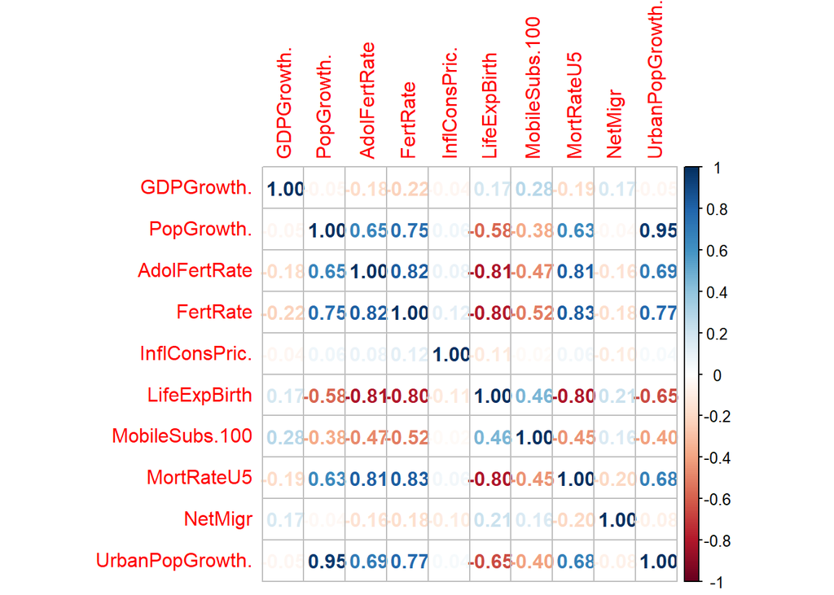

```r
corrplot(cor(vardep), method= "number")
```

Esta tabla nos muestra las correlaciones lineales que existen entre las regresoras de nuestro modelo. La variable explicada tiene una correlación relativamente pequeña con todas las variables. Del mismo modo, el crecimiento del PIB muestra una correlación negativa con el crecimiento poblacional, la tasa de fertilidad adolescente, tasa de fertilidad, la inflación, la tasa de mortalidad infantil de niños menores a cinco años y el crecimiento de la población urbana. Esto nos indica que si alguna de estas seis regresoras aumenta en una unidad o, en el caso de las tasas, en un 0.01, la variable dependiente disminuirá en un 1%. Por otro lado, el crecimiento del PIB goza de una correlación directa con la esperanza de vida al nacer y la tasa de suscripciones de teléfono.

Ahora bien, podemos observar que el crecimiento poblacional y el crecimiento de la población urbana tienen una correlación positiva de más de 0.7. Las variables relacionadas con los nacimientos o la fertilidad están altamente correlacionadas con la tasa de mortalidad infantil de menores a cinco años. La migración neta no se encuentra muy correlacionada con ninguna variable; sin embargo, tiene una correlación negativa con la tasa de mortalidad infantil de menores a cinco años. Las variables de las tasas de fertilidad y la esperanza de vida al nacer claramente están altamente correlacionadas entre ellas.

```r
# R2 y Significancia
stargazer(reg1,type="text")
```

```
##
## ===============================================
##                         Dependent variable:
##                     ---------------------------
##                             GDPGrowth.
## -----------------------------------------------
## PopGrowth.                     0.015
##                               (1.145)
##
## AdolFertRate                  -0.005
##                               (0.023)
##
## FertRate                      -1.538*
##                               (0.817)
##
## InflConsPric.                 -0.001
##                               (0.018)
##
## LifeExpBirth                  -0.042
##                               (0.112)
##
## MobileSubs.100               0.036***
##                               (0.013)
##
## MortRateU5                    -0.008
##                               (0.034)
##
## NetMigr                       0.00001
##                              (0.00000)
##
## UrbanPopGrowth.                1.086
##                               (0.934)
##
## Constant                       6.593
##                               (9.385)
##
## -----------------------------------------------
## Observations                    201
## R2                             0.133
## Adjusted R2                    0.092
## Residual Std. Error      6.008 (df = 191)
## F Statistic           3.263*** (df = 9; 191)
## ===============================================
## Note:               *p<0.1; **p<0.05; ***p<0.01
```

El R² de nuestro modelo es bajo y también el R² ajustado. Sin embargo, las variables que muestran significancia son la tasa de suscripciones de teléfono y la tasa de fertilidad. Las otras variables no son significativas. Ambas tasas de fertilidad están relacionadas indirectamente con el crecimiento económico, pero la tasa de fertilidad es la significativa.

**FIV y TOL: Flactor Inflador de la Varianza y Tolerancia**

El FIV nos indica que tan “inflada” está la varianza de un estimador por la presencia de multicolinealidad. Cuando el FIV es mayor a 10 comenzamos a preocuparnos por la multicolinealidad.

El TOL es el recíproco del FIV, por lo que queremos que este sea un número mayor a cero, pero menor a 1.

```r
# Factor inflador de la varianza (FIV) y Tolerancia (TOL)

vif(reg1)
```

```
##      PopGrowth.    AdolFertRate        FertRate   InflConsPric.    LifeExpBirth
##       12.664912        4.237572        5.761203        1.049391        4.018555
##  MobileSubs.100      MortRateU5         NetMigr UrbanPopGrowth.
##        1.390548        4.232377        1.091766       13.684090
```

```r
(tol <- 1/vif(reg1))
```

```
##      PopGrowth.    AdolFertRate        FertRate   InflConsPric.    LifeExpBirth
##      0.07895831      0.23598421      0.17357485      0.95293365      0.24884567
##  MobileSubs.100      MortRateU5         NetMigr UrbanPopGrowth.
##      0.71914072      0.23627386      0.91594696      0.07307757
```

En este caso, es preferible cuando el factor inflador de la varianza es menor a diez. Dicho esto, nuestro modelo muestra que las variables de crecimiento poblacional y el crecimiento de la población urbana claramente "inflan" su propia varianza. De este modo, podemos observar la existencia de la multicolinealidad en nuestro modelo. Ahora bien, la tolerancia muestra lo mismo. Pero es importante mencionar que las variables más cercanas a uno son la inflación y la migración neta.

## **Verificación de Heteroscedasticidad**

La hetersocedasticidad ocurre cuando la varianza de los residuales no es constante. Lo que buscamos es que los residuales varíen sobre un mismo rango. Este gráfico nos indica que nuestros residuales se están comportando como lo esperado. Es posible apreciar algunas partes en las que puede aumentar o disminuir la varianza; sin embargo, estos cambios son pocos.

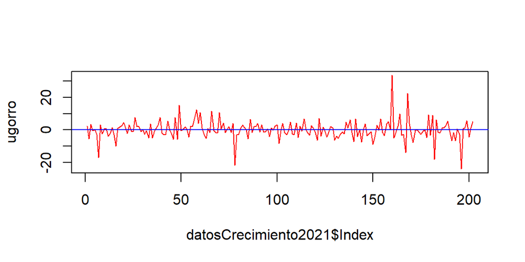

```r
plot(datosCrecimiento2021$Index,ugorro,type="l",col="red")
abline(h=0, col="blue")
```

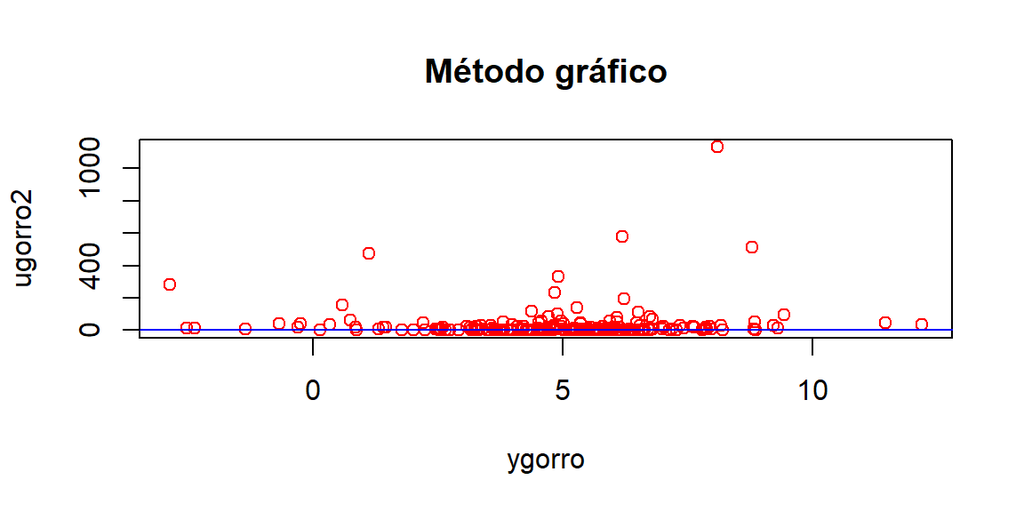

```r
ugorro2<-ugorro^2
plot(ygorro,ugorro2,type="p",col="red",main="Método gráfico")
abline(h=0, col="blue")
```

Este gráfico de dispersión de los residuales nos muestra como nuestro término estocástico varía en una misma banda de valores. Se pueden apreciar observaciones atípicas, las cuales gozan de una variabilidad diferente a la mayoría. Esto podría ser ocasionado por la misma naturaleza de nuestros datos.

**Prueba de Breusch, Pagan y Godfrey**

La prueba de Breusch, Pagan y Godfrey necesita el supuesto de normalidad. Sin embargo, para fines de un ejercicio de práctica intentemos interpretar sus resultados.

```r
bptest(reg1)
```

```
##
##  studentized Breusch-Pagan test
##
## data:  reg1
## BP = 8.5218, df = 9, p-value = 0.4825
```

Nuestro valor p es mayor que el nivel de significancia. Dicho esto, no rechazamos la hipótesis nula, la cual se refiere al hecho de que hay homocedasticidad. Nuestro valor p es considerablemente grande. Esto nos indica que, a pesar de la presencia de datos atípicos en los gráficos pasados, no hay heterocedasticidad en nuestro término aleatorio.

**Prueba de Glejser y Prueba de Park**

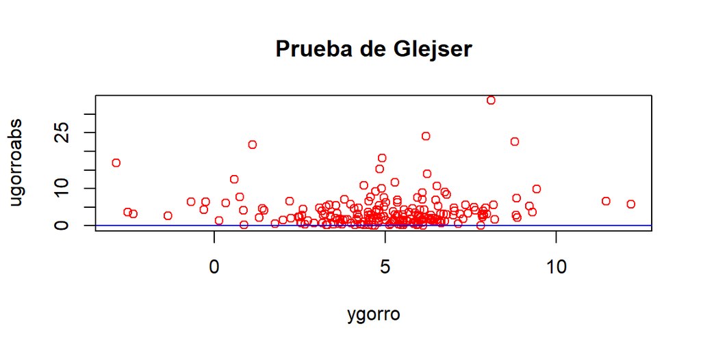

```r
# Prueba de Glejser

ugorroabs<-abs(ugorro)
plot(ygorro,ugorroabs,type="p",col="red",
     main="Prueba de Glejser")
abline(h=0, col="blue")
```

```r
aux3h<-lm(ugorroabs~PopGrowth.+AdolFertRate+FertRate+InflConsPric.+LifeExpBirth+MobileSubs.100+MortRateU5+NetMigr+UrbanPopGrowth.)
H03h<-c("PopGrowth.=0", "InflConsPric.=0","FertRate=0","LifeExpBirth=0","AdolFertRate=0","MobileSubs.100=0", "MortRateU5=0","NetMigr=0","UrbanPopGrowth.=0")
linearHypothesis(aux3h,H03h)
```

```
## Linear hypothesis test
##
## Hypothesis:
## PopGrowth. = 0
## InflConsPric. = 0
## FertRate = 0
## LifeExpBirth = 0
## AdolFertRate = 0
## MobileSubs.100 = 0
## MortRateU5 = 0
## NetMigr = 0
## UrbanPopGrowth. = 0
##
## Model 1: restricted model
## Model 2: ugorroabs ~ PopGrowth. + AdolFertRate + FertRate + InflConsPric. +
##     LifeExpBirth + MobileSubs.100 + MortRateU5 + NetMigr + UrbanPopGrowth.
##
##   Res.Df    RSS Df Sum of Sq      F Pr(>F)
## 1    200 3935.0
## 2    191 3696.5  9    238.49 1.3692 0.2045
```

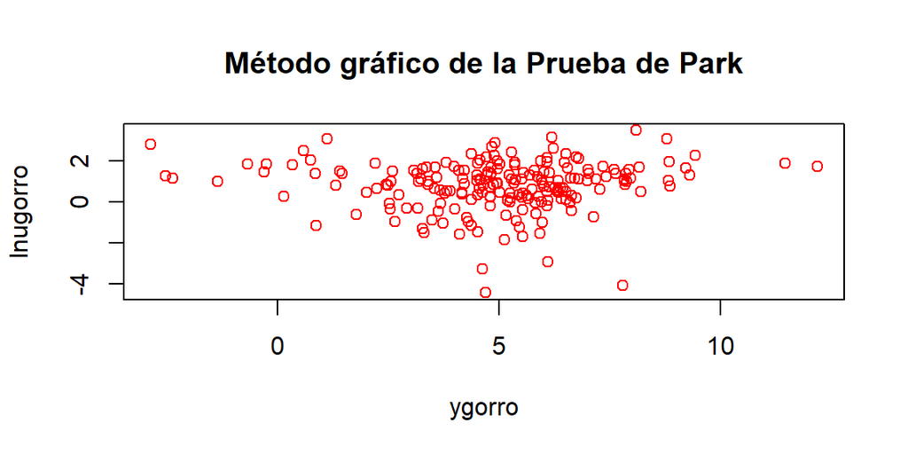

```r
# Prueba de Park

lnugorro<-log(ugorroabs)
plot(ygorro,lnugorro,type="p",col="red",
     main="Método gráfico de la Prueba de Park")
```

```r
aux4h<-lm(lnugorro~PopGrowth.+AdolFertRate+FertRate+InflConsPric.+LifeExpBirth+MobileSubs.100+MortRateU5+NetMigr+UrbanPopGrowth.)
H04h<-c("PopGrowth.=0", "InflConsPric.=0","FertRate=0","LifeExpBirth=0","AdolFertRate=0","MobileSubs.100=0", "MortRateU5=0","NetMigr=0","UrbanPopGrowth.=0")
linearHypothesis(aux4h,H04h)
```

```
## Linear hypothesis test
##
## Hypothesis:
## PopGrowth. = 0
## InflConsPric. = 0
## FertRate = 0
## LifeExpBirth = 0
## AdolFertRate = 0
## MobileSubs.100 = 0
## MortRateU5 = 0
## NetMigr = 0
## UrbanPopGrowth. = 0
##
## Model 1: restricted model
## Model 2: lnugorro ~ PopGrowth. + AdolFertRate + FertRate + InflConsPric. +
##     LifeExpBirth + MobileSubs.100 + MortRateU5 + NetMigr + UrbanPopGrowth.
##
##   Res.Df    RSS Df Sum of Sq      F Pr(>F)
## 1    200 292.16
## 2    191 278.47  9    13.694 1.0436 0.4069
```

Ambas pruebas nos muestran los mismos resultados que la prueba de Breusch, Pagan y Godfrey, el p-value es mayor a 0.1, por lo que rechazo que haya Heteroscedasticidad en el modelo. Pero, ¿por qué no intentamos con la prueba más general

**Prueba de White**

```r
white(reg1,interactions = TRUE)
```

```
## # A tibble: 1 × 5
##   statistic p.value parameter method       alternative
##       <dbl>   <dbl>     <dbl> <chr>        <chr>
## 1      63.8   0.170        54 White's Test greater
```

La prueba de White utiliza una regresión auxiliar más general, pues incluye como regresores no solo las variables originales lineales, sino también de manera cuadrática y de orden dos. En este caso el p- value confirma que el modelo modelo no tiene un problema de Heteroscedasticidad.

Ahora bien, necesitamos comprobar que no existe autocorrelación entre nuestros residuales para asegurarnos que no se viola el quinto supuesto del modelo de regresión lineal múltiple.

## No Autocorrelación

**Método Gráfico**

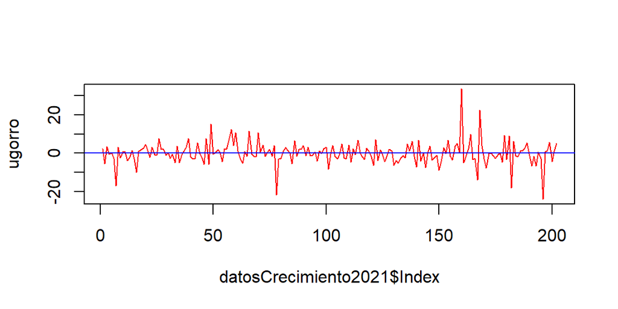

```r
# Método gráfico
plot(datosCrecimiento2021$Index,ugorro,type="l",col="red")
abline(h=0, col="blue")
```

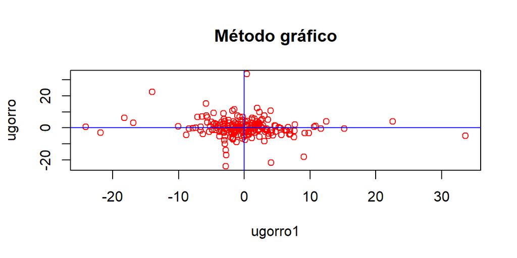

```r
ugorro1<-vector()
for(i in 2:n){ugorro1[i]<-ugorro[i-1]}
plot(ugorro1,ugorro,type="p",col="red",main="Método gráfico")
abline(h=0,col="blue")
abline(v=0,col="blue")
```

Estos dos gráficos nos muestran que el término estocástico del modelo no sigue ningún tipo de patrón. El diagrama de dispersión revela el hecho de que los residuos se comportan como un término esférico.

**Prueba de Durbin - Watson**

```r
# Prueba de Durbin-Watson

dwtest(reg1)
```

```
##
##  Durbin-Watson test
##
## data:  reg1
## DW = 2.2627, p-value = 0.9671
## alternative hypothesis: true autocorrelation is greater than 0
```

El valor p nos arroja un número considerablemente grande. Dicho esto, no se rechaza la hipótesis nula, la cual se refiere a que el modelo no presenta autocorrelación de primer orden.

**Prueba de Breusch y Godfrey**

```r
# Prueba de Breusch y Godfrey

bgtest(reg1)
```

```
##
##  Breusch-Godfrey test for serial correlation of order up to 1
##
## data:  reg1
## LM test = 3.8292, df = 1, p-value = 0.05037
```

## **Verificación de Exogeneidad**

Probemos si cumple el supuesto de Endogeneidad con el Reset Test.

```r
# *******************************************
#       Supuesto: Exogeneidad
# *******************************************

resettest(reg1, power=2, type="fitted")
```

```
##
##  RESET test
##
## data:  reg1
## RESET = 1.1647, df1 = 1, df2 = 190, p-value = 0.2819
```

En este caso, el valor p es mayor que el nivel de significancia del modelo. Por esta razón, ¡nuestro modelo parece estar bien especificado!

# Corrección del modelo

## Corrección 1. Modelo ascendente

Elaboramos diferentes modelos para analizar la significancia, de cada una de las diferentes variables. Esto se llevó a cabo debido a que la correlación entre algunas variables era considerablemente alta, como en el caso del crecimiento poblacional y el crecimiento de la población urbana. Las regresoras de tasa de fertilidad y tasa de fertilidad adolescente también presentan una correlación elevada entre ellas.

```r
RegAux1 <- lm (GDPGrowth.~MobileSubs.100, data=datosCrecimiento2021)
RegAux2 <- lm (GDPGrowth.~MobileSubs.100+UrbanPopGrowth.,data=datosCrecimiento2021)
RegAux3 <- lm (GDPGrowth.~MobileSubs.100+UrbanPopGrowth.+FertRate,data=datosCrecimiento2021)
RegAux4 <- lm (GDPGrowth.~MobileSubs.100+UrbanPopGrowth.+FertRate+LifeExpBirth, data=datosCrecimiento2021)
RegAux5<- lm (GDPGrowth.~MobileSubs.100+UrbanPopGrowth.+FertRate+LifeExpBirth+MortRateU5, data=datosCrecimiento2021)
RegAux6<- lm (GDPGrowth.~MobileSubs.100+UrbanPopGrowth.+FertRate+LifeExpBirth+MortRateU5+NetMigr, data=datosCrecimiento2021)
RegAux7<- lm (GDPGrowth.~MobileSubs.100+UrbanPopGrowth.+FertRate+LifeExpBirth+MortRateU5+NetMigr+InflConsPric., data=datosCrecimiento2021)
RegAux8<- lm (GDPGrowth.~MobileSubs.100+UrbanPopGrowth.+FertRate+LifeExpBirth+MortRateU5+NetMigr+InflConsPric.+AdolFertRate, data=datosCrecimiento2021)
RegAux9<- lm (GDPGrowth.~MobileSubs.100+UrbanPopGrowth.+FertRate+LifeExpBirth+MortRateU5+NetMigr+InflConsPric.+AdolFertRate+PopGrowth., data=datosCrecimiento2021)

library (stargazer)
lista <- list(RegAux1,RegAux2,RegAux3,RegAux4,RegAux5,RegAux6,RegAux7,RegAux8,RegAux9)

stargazer(lista,type = "text")
```

```
##
## ===================================================================================================================================================================================================================================
##                                                                                                                   Dependent variable:
##                     ---------------------------------------------------------------------------------------------------------------------------------------------------------------------------------------------------------------
##                                                                                                                       GDPGrowth.
##                               (1)                    (2)                    (3)                    (4)                    (5)                    (6)                    (7)                    (8)                    (9)
## -----------------------------------------------------------------------------------------------------------------------------------------------------------------------------------------------------------------------------------
## MobileSubs.100             0.046***                0.051***               0.038***               0.038***               0.038***               0.036***               0.036***               0.036***               0.036***
##                             (0.011)                (0.012)                (0.013)                (0.013)                (0.013)                (0.013)                (0.013)                (0.013)                (0.013)
##
## UrbanPopGrowth.                                     0.290                 1.144***               1.142***               1.155***               1.088***               1.086***               1.097***                1.086
##                                                    (0.279)                (0.393)                (0.395)                (0.397)                (0.399)                (0.401)                (0.405)                (0.934)
##
## FertRate                                                                 -1.713***               -1.732**               -1.608**               -1.582**               -1.577**               -1.536*                -1.538*
##                                                                           (0.565)                (0.692)                (0.762)                (0.760)                (0.768)                (0.791)                (0.817)
##
## LifeExpBirth                                                                                      -0.005                 -0.021                 -0.033                 -0.034                 -0.042                 -0.042
##                                                                                                  (0.093)                (0.102)                (0.102)                (0.102)                (0.108)                (0.112)
##
## MortRateU5                                                                                                               -0.013                 -0.010                 -0.010                 -0.008                 -0.008
##                                                                                                                         (0.032)                (0.032)                (0.032)                (0.034)                (0.034)
##
## NetMigr                                                                                                                                        0.00001                0.00001                0.00001                0.00001
##                                                                                                                                               (0.00000)              (0.00000)              (0.00000)              (0.00000)
##
## InflConsPric.                                                                                                                                                          -0.001                 -0.001                 -0.001
##                                                                                                                                                                       (0.018)                (0.018)                (0.018)
##
## AdolFertRate                                                                                                                                                                                  -0.005                 -0.005
##                                                                                                                                                                                              (0.023)                (0.023)
```

[output cut: 15 more lines]

El crecimiento de la población urbana no fue eliminado debido a que podemos analizar cómo su integración en el segundo modelo aumenta el R². Esto quiere decir que las variaciones de esta regresora si ayudan a explicar las variaciones del crecimiento económico. Del mismo modo, la tasa de fertilidad aumenta el R² ajustado en el tercer modelo.

Ahora bien, realizando todos estos modelos nos dimos cuenta que las regresiones que presentaban el R² mayor eran la sexta y séptima. Sin embargo, el R² ajustado de la última regresión disminuye con la presencia de la tasa de fertilidad adolescente. Dicho esto, optamos por el penúltimo modelo. Nuestro nuevo modelo goza de un R² y R² ajustado mayor.

```r
RegAux1B <- lm (GDPGrowth.~MobileSubs.100, data=datosCrecimiento2021)
RegAux2B <- lm (GDPGrowth.~MobileSubs.100+UrbanPopGrowth.,data=datosCrecimiento2021)
RegAux3B <- lm (GDPGrowth.~MobileSubs.100+UrbanPopGrowth.+FertRate,data=datosCrecimiento2021)
RegAux4B <- lm (GDPGrowth.~MobileSubs.100+UrbanPopGrowth.+FertRate+LifeExpBirth, data=datosCrecimiento2021)
RegAux5B<- lm (GDPGrowth.~MobileSubs.100+UrbanPopGrowth.+FertRate+LifeExpBirth+MortRateU5, data=datosCrecimiento2021)
RegAux6B<- lm (GDPGrowth.~MobileSubs.100+UrbanPopGrowth.+FertRate+LifeExpBirth+MortRateU5+NetMigr, data=datosCrecimiento2021)
RegAux7B<- lm (GDPGrowth.~MobileSubs.100+UrbanPopGrowth.+FertRate+LifeExpBirth+MortRateU5+NetMigr+AdolFertRate, data=datosCrecimiento2021)


listaB <- list(RegAux1B,RegAux2B,RegAux3B,RegAux4B,RegAux5B,RegAux6B,RegAux7B)

stargazer(listaB,type = "text")
```

```
##
## =====================================================================================================================================================================================
##                                                                                            Dependent variable:
##                     -----------------------------------------------------------------------------------------------------------------------------------------------------------------
##                                                                                                GDPGrowth.
##                               (1)                    (2)                    (3)                    (4)                    (5)                    (6)                    (7)
## -------------------------------------------------------------------------------------------------------------------------------------------------------------------------------------
## MobileSubs.100             0.046***                0.051***               0.038***               0.038***               0.038***               0.036***               0.036***
##                             (0.011)                (0.012)                (0.013)                (0.013)                (0.013)                (0.013)                (0.013)
##
## UrbanPopGrowth.                                     0.290                 1.144***               1.142***               1.155***               1.088***               1.098***
##                                                    (0.279)                (0.393)                (0.395)                (0.397)                (0.399)                (0.403)
##
## FertRate                                                                 -1.713***               -1.732**               -1.608**               -1.582**               -1.540*
##                                                                           (0.565)                (0.692)                (0.762)                (0.760)                (0.783)
##
## LifeExpBirth                                                                                      -0.005                 -0.021                 -0.033                 -0.041
##                                                                                                  (0.093)                (0.102)                (0.102)                (0.108)
##
## MortRateU5                                                                                                               -0.013                 -0.010                 -0.007
##                                                                                                                         (0.032)                (0.032)                (0.033)
##
## NetMigr                                                                                                                                        0.00001                0.00001
##                                                                                                                                               (0.00000)              (0.00000)
##
## AdolFertRate                                                                                                                                                           -0.005
##                                                                                                                                                                       (0.023)
##
## Constant                    -0.115                  -1.144                 3.367                  3.745                  4.906                  5.905                  6.536
##                             (1.315)                (1.646)                (2.195)                (7.890)                (8.438)                (8.444)                (8.911)
##
## -------------------------------------------------------------------------------------------------------------------------------------------------------------------------------------
## Observations                  201                    201                    201                    201                    201                    201                    201
## R2                           0.077                  0.082                  0.123                  0.123                  0.124                  0.133                  0.133
## Adjusted R2                  0.073                  0.073                  0.110                  0.105                  0.101                  0.106                  0.102
## Residual Std. Error    6.074 (df = 199)        6.072 (df = 198)       5.951 (df = 197)       5.966 (df = 196)       5.979 (df = 195)       5.962 (df = 194)       5.977 (df = 193)
## F Statistic         16.652*** (df = 1; 199) 8.868*** (df = 2; 198) 9.220*** (df = 3; 197) 6.880*** (df = 4; 196) 5.512*** (df = 5; 195) 4.960*** (df = 6; 194) 4.238*** (df = 7; 193)
## =====================================================================================================================================================================================
## Note:                                                                                                                                                     *p<0.1; **p<0.05; ***p<0.01
```

```r
# Modelo Simplificado
stargazer(RegAux6B,type = "text")
```

```
##
## ===============================================
##                         Dependent variable:
##                     ---------------------------
##                             GDPGrowth.
## -----------------------------------------------
## MobileSubs.100               0.036***
##                               (0.013)
##
## UrbanPopGrowth.              1.088***
##                               (0.399)
##
## FertRate                     -1.582**
##                               (0.760)
##
## LifeExpBirth                  -0.033
##                               (0.102)
##
## MortRateU5                    -0.010
##                               (0.032)
##
## NetMigr                       0.00001
##                              (0.00000)
##
## Constant                       5.905
##                               (8.444)
##
## -----------------------------------------------
## Observations                    201
## R2                             0.133
## Adjusted R2                    0.106
## Residual Std. Error      5.962 (df = 194)
## F Statistic           4.960*** (df = 6; 194)
## ===============================================
## Note:               *p<0.1; **p<0.05; ***p<0.01
```

Ahora, para comprobar como se desempeña este nuevo modelo, realizamos las pruebas para la verificación de supuestos.

```r
modelo<-RegAux6B
jarque.bera.test(modelo$residuals)
```

```
##
##  Jarque Bera Test
##
## data:  modelo$residuals
## X-squared = 528.11, df = 2, p-value < 2.2e-16
```

```r
vif(modelo)
```

```
##  MobileSubs.100 UrbanPopGrowth.        FertRate    LifeExpBirth      MortRateU5
##        1.378299        2.538110        5.064774        3.376760        3.867005
##         NetMigr
##        1.071126
```

```r
bptest(modelo)
```

```
##
##  studentized Breusch-Pagan test
##
## data:  modelo
## BP = 6.8619, df = 6, p-value = 0.3338
```

```r
white(modelo,interactions = TRUE)
```

```
## # A tibble: 1 × 5
##   statistic p.value parameter method       alternative
##       <dbl>   <dbl>     <dbl> <chr>        <chr>
## 1      26.1   0.511        27 White's Test greater
```

```r
dwtest(modelo)
```

```
##
##  Durbin-Watson test
##
## data:  modelo
## DW = 2.2596, p-value = 0.966
## alternative hypothesis: true autocorrelation is greater than 0
```

```r
bgtest(modelo)
```

```
##
##  Breusch-Godfrey test for serial correlation of order up to 1
##
## data:  modelo
## LM test = 3.6359, df = 1, p-value = 0.05654
```

```r
resettest(modelo, power=2, type="fitted")
```

```
##
##  RESET test
##
## data:  modelo
## RESET = 1.0893, df1 = 1, df2 = 193, p-value = 0.2979
```

- **Prueba Jarque Bera:** El término aleatorio claramente sigue sin ser normal. El valor p es considerablemente menor que el nivel de significancia. La hipótesis nula es rechazada, por lo que, los residuales no se comportan de manera normal.
- **FIV:** La eliminación de la variables del crecimiento poblacional y la tasa de fertilidad adolescente ayudaron a que el factor que infla a la varianza disminuya. Ninguna de las regresoras presenta un factor mayor a 10.
- **Prueba Breush Pagan y Godfrey:** El valor p sigue siendo mayor que el nivel de significancia. No se rechaza la hipótesis nula. Por ello, el término estocástico no presenta heterocedasticidad.
- **Prueba Durbin-Watson:** El valor p es mayor que el nivel de significancia. Dicho esto, el término aleatorio no presenta autocorrelación de primer orden.
- **Prueba de especificación:** El valor continúa siendo mayor que el nivel de significancia. A pesar de haber eliminado variables y observaciones, el modelo está bien especificado.
- **Prueba de White:** En este caso el p- value confirma que el modelo no tiene un problema de Heteroscedasticidad cuando tomamos un modelo más general (términos cuadráticos y de orden dos).

**Regresiones Auxiliares de Klein.**

```r
aux1m<-lm(MobileSubs.100~UrbanPopGrowth.+FertRate+LifeExpBirth+MortRateU5+NetMigr,data=datosCrecimiento2021)
aux2m<-lm(UrbanPopGrowth.~MobileSubs.100+FertRate+LifeExpBirth+MortRateU5+NetMigr,data=datosCrecimiento2021)
aux3m<-lm(FertRate~UrbanPopGrowth.+MobileSubs.100+LifeExpBirth+MortRateU5+NetMigr,data=datosCrecimiento2021)
aux4m<-lm(LifeExpBirth~UrbanPopGrowth.+FertRate+MobileSubs.100+MortRateU5+NetMigr,data=datosCrecimiento2021)
aux5m<-lm(MortRateU5~UrbanPopGrowth.+FertRate+LifeExpBirth+MobileSubs.100+NetMigr,data=datosCrecimiento2021)
aux6m<-lm(NetMigr~UrbanPopGrowth.+FertRate+LifeExpBirth+MortRateU5+MobileSubs.100,data=datosCrecimiento2021)

stargazer(aux1m,aux2m,aux3m,aux4m,aux5m,aux6m,type="text")
```

```
##
## ==============================================================================================================
##                                                              Dependent variable:
##                                -------------------------------------------------------------------------------
##                                MobileSubs.100 UrbanPopGrowth.  FertRate  LifeExpBirth MortRateU5    NetMigr
##                                     (1)             (2)          (3)         (4)         (5)          (6)
## --------------------------------------------------------------------------------------------------------------
## UrbanPopGrowth.                    -0.379                      0.237***     -0.238      1.056      9,940.647
##                                   (2.195)                      (0.034)     (0.280)     (0.890)    (6,036.451)
##
## MobileSubs.100                                    -0.0004     -0.004***     0.009       -0.001      191.856
##                                                   (0.002)      (0.001)     (0.009)     (0.029)     (197.855)
##
## FertRate                         -12.232***      0.860***                 -2.288***    9.792***   -3,923.932
##                                   (4.088)         (0.122)                  (0.509)     (1.551)   (11,574.170)
##
## LifeExpBirth                       0.532          -0.015      -0.041***               -1.263***    1,865.405
##                                   (0.559)         (0.018)      (0.009)                 (0.209)    (1,544.741)
##
## MortRateU5                         -0.008          0.007       0.017***   -0.125***                -447.679
##                                   (0.176)         (0.006)      (0.003)     (0.021)                 (486.075)
##
## NetMigr                           0.00003         0.00000      -0.00000    0.00000     -0.00001
##                                  (0.00003)       (0.00000)    (0.00000)   (0.00000)   (0.00001)
##
## Constant                         103.949**         0.367       5.040***   80.022***   90.275***  -148,264.600
##                                   (45.851)        (1.515)      (0.709)     (1.570)     (17.773)  (128,209.800)
##
## --------------------------------------------------------------------------------------------------------------
## Observations                        201             201          201         201         201          201
## R2                                 0.274           0.606        0.803       0.704       0.741        0.066
## Adjusted R2                        0.256           0.596        0.797       0.696       0.735        0.042
## Residual Std. Error (df = 195)     32.799          1.070        0.562       4.195       13.354    90,837.760
## F Statistic (df = 5; 195)        14.754***       59.986***    158.526***  92.694***   111.813***    2.774**
## ==============================================================================================================
## Note:                                                                              *p<0.1; **p<0.05; ***p<0.01
```

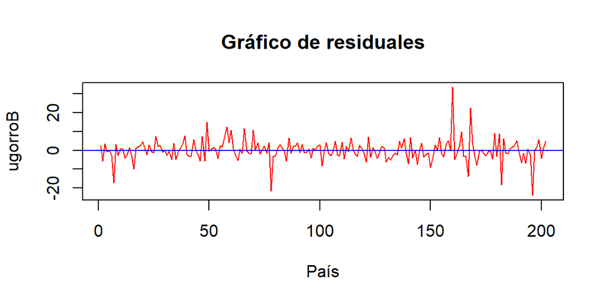

```r
k<-6
ygorroB<-RegAux6B$fitted.values
ugorroB<-RegAux6B$residuals
sigma2B<-sum(ugorroB^2)/(n-k-1)

plot(datosCrecimiento2021$Index,ugorroB,type="l",
     col="red",
     main="Gráfico de residuales",
     xlab = "País")
abline(h=0, col="blue")
```

No obstante, nuestros residuales continúan comportándose de buena manera. No presentan autocorrelación ni heterocedasticidad. Este gráfico nos muestra que los residuales varían sobre un mismo rango y que no existe ningún patrón.

## Corrección 2. Modelos ascendentes para corregir multicolinealidad

```r
RegAux1C<- lm (GDPGrowth.~MobileSubs.100+UrbanPopGrowth.+FertRate+LifeExpBirth+NetMigr, data=datosCrecimiento2021)
RegAux2C<- lm (GDPGrowth.~MobileSubs.100+UrbanPopGrowth.+FertRate+NetMigr+MortRateU5, data=datosCrecimiento2021)
RegAux3C<- lm (GDPGrowth.~MobileSubs.100+UrbanPopGrowth.+FertRate+LifeExpBirth+MortRateU5, data=datosCrecimiento2021)
RegAux4C<- lm (GDPGrowth.~MobileSubs.100+UrbanPopGrowth.+FertRate+LifeExpBirth+MortRateU5+NetMigr, data=datosCrecimiento2021)

listaC <- list(RegAux1C,RegAux2C,RegAux3C,RegAux4C)
stargazer(listaC,type = "text")
```

```
##
## ===============================================================================================================
##                                                         Dependent variable:
##                     -------------------------------------------------------------------------------------------
##                                                             GDPGrowth.
##                              (1)                    (2)                    (3)                    (4)
## ---------------------------------------------------------------------------------------------------------------
## MobileSubs.100             0.036***               0.036***               0.038***               0.036***
##                            (0.013)                (0.013)                (0.013)                (0.013)
##
## UrbanPopGrowth.            1.077***               1.095***               1.155***               1.088***
##                            (0.397)                (0.397)                (0.397)                (0.399)
##
## FertRate                   -1.675**               -1.505**               -1.608**               -1.582**
##                            (0.691)                (0.722)                (0.762)                (0.760)
##
## LifeExpBirth                -0.021                                        -0.021                 -0.033
##                            (0.093)                                       (0.102)                (0.102)
##
## NetMigr                    0.00001                0.00001                                       0.00001
##                           (0.00000)              (0.00000)                                     (0.00000)
##
## MortRateU5                                         -0.005                 -0.013                 -0.010
##                                                   (0.029)                (0.032)                (0.032)
##
## Constant                    5.039                  3.231                  4.906                  5.905
##                            (7.917)                (2.227)                (8.438)                (8.444)
##
## ---------------------------------------------------------------------------------------------------------------
## Observations                 201                    201                    201                    201
## R2                          0.133                  0.133                  0.124                  0.133
## Adjusted R2                 0.110                  0.110                  0.101                  0.106
## Residual Std. Error    5.949 (df = 195)       5.949 (df = 195)       5.979 (df = 195)       5.962 (df = 194)
## F Statistic         5.962*** (df = 5; 195) 5.958*** (df = 5; 195) 5.512*** (df = 5; 195) 4.960*** (df = 6; 194)
## ===============================================================================================================
## Note:                                                                               *p<0.1; **p<0.05; ***p<0.01
```

Ahora bien, la primera regresión no mostró buenos resultados en el supuesto de homocedasticidad. El modelo tenía un valor p menor que el nivel de significancia en la prueba de Breusch, Godfrey y Pagan. Dicho esto, optamos por elegir el segundo modelo. Esta regresión ahora no incluye a la esperanza de vida al nacer. Asimismo, esta variable estaba altamente correlacionada con la tasa de fertilidad, la cual es significativa en este nuevo modelo.

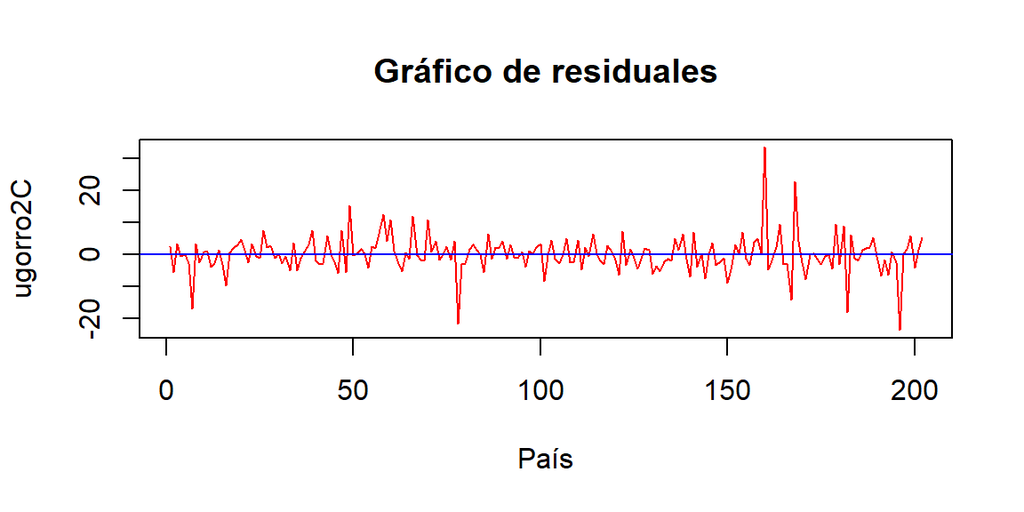

```r
k<-5
ygorro2C<-RegAux2C$fitted.values
ugorro2C<-RegAux2C$residuals
sigma2C<-sum(ugorro2C^2)/(n-k-1)

plot(datosCrecimiento2021$Index,ugorro2C,type="l",
     col="red",
     main="Gráfico de residuales",
     xlab = "País")
abline(h=0, col="blue")
```

Los residuales de nuestra nueva regresión se siguen comportando de buena manera. no presentan ningún patrón y su variabilidad está sujeta a un mismo rango.

Recordemos el modelo que hasta el momento se ha desempeñado mejor y apliquemos las pruebas para comprobar los supuestos.

```r
RegAlmost <- RegAux2C
stargazer(RegAlmost,type = "text")
```

```
##
## ===============================================
##                         Dependent variable:
##                     ---------------------------
##                             GDPGrowth.
## -----------------------------------------------
## MobileSubs.100               0.036***
##                               (0.013)
##
## UrbanPopGrowth.              1.095***
##                               (0.397)
##
## FertRate                     -1.505**
##                               (0.722)
##
## NetMigr                       0.00001
##                              (0.00000)
##
## MortRateU5                    -0.005
##                               (0.029)
##
## Constant                       3.231
##                               (2.227)
##
## -----------------------------------------------
## Observations                    201
## R2                             0.133
## Adjusted R2                    0.110
## Residual Std. Error      5.949 (df = 195)
## F Statistic           5.958*** (df = 5; 195)
## ===============================================
## Note:               *p<0.1; **p<0.05; ***p<0.01
```

```r
modelo<-RegAlmost
jarque.bera.test(modelo$residuals)
```

```
##
##  Jarque Bera Test
##
## data:  modelo$residuals
## X-squared = 516.33, df = 2, p-value < 2.2e-16
```

```r
vif(modelo)
```

```
##  MobileSubs.100 UrbanPopGrowth.        FertRate         NetMigr      MortRateU5
##        1.371907        2.528761        4.589361        1.063175        3.258038
```

```r
bptest(modelo)
```

```
##
##  studentized Breusch-Pagan test
##
## data:  modelo
## BP = 6.9024, df = 5, p-value = 0.228
```

```r
white(modelo,interactions = TRUE)
```

```
## # A tibble: 1 × 5
##   statistic p.value parameter method       alternative
##       <dbl>   <dbl>     <dbl> <chr>        <chr>
## 1      20.1   0.454        20 White's Test greater
```

```r
dwtest(modelo)
```

```
##
##  Durbin-Watson test
##
## data:  modelo
## DW = 2.2596, p-value = 0.9666
## alternative hypothesis: true autocorrelation is greater than 0
```

```r
bgtest(modelo)
```

```
##
##  Breusch-Godfrey test for serial correlation of order up to 1
##
## data:  modelo
## LM test = 3.6266, df = 1, p-value = 0.05686
```

```r
resettest(modelo, power=2, type="fitted")
```

```
##
##  RESET test
##
## data:  modelo
## RESET = 1.0796, df1 = 1, df2 = 194, p-value = 0.3001
```

- **Prueba Jarque Bera:** El valor p continúa siendo menor que el nivel de significancia. Por ello, nuestro término estocástico no se distribuye de manera normal.
- **FIV:** El factor inflador de la varianza continúa siendo menor que diez para las cinco regresoras que tenemos. Sin embargo, tenemos que aplicar la regla de Klein para asegurarnos de que no exista multicolinealidad imperfecta, pero elevada.
- **Prueba Breush Pagan y Godfrey:**El valor p es muy parecido a nuestro nivel de significancia, pero sigue siendo mayor. Nuestro modelo no presenta autocorrelación de orden superior.
- **Prueba Durbin-Watson:** El valor p es mayor que nuestro nivel de significancia, el es 0.05. Dicho esto, nuestro modelo no presenta autocorrelación de primer orden.
- **Prueba de especificación:** El valor p es mayor que nuestro nivel de significancia. A pesar de haber eliminado la variable de esperanza de vida al nacer, el modelo se encuentra bien especificado.
- **Prueba de White:** En este caso el p- value confirma que el modelo no tiene un problema de Heteroscedasticidad cuando tomamos un modelo más general (términos cuadráticos y de orden dos).

**Prueba de Klein Modelo RegAlmost**

```r
aux1m<-lm(MobileSubs.100~UrbanPopGrowth.+FertRate+MortRateU5+NetMigr,data=datosCrecimiento2021)
aux2m<-lm(UrbanPopGrowth.~MobileSubs.100+FertRate+MortRateU5+NetMigr,data=datosCrecimiento2021)
aux3m<-lm(FertRate~UrbanPopGrowth.+MobileSubs.100+MortRateU5+NetMigr,data=datosCrecimiento2021)
aux4m<-lm(MortRateU5~UrbanPopGrowth.+FertRate+MobileSubs.100+NetMigr,data=datosCrecimiento2021)
aux5m<-lm(NetMigr~UrbanPopGrowth.+FertRate+MortRateU5+MobileSubs.100,data=datosCrecimiento2021)

stargazer(aux1m,aux2m,aux3m,aux4m,aux5m,type="text")
```

```
##
## ================================================================================================
##                                                       Dependent variable:
##                                -----------------------------------------------------------------
##                                MobileSubs.100 UrbanPopGrowth.  FertRate  MortRateU5   NetMigr
##                                     (1)             (2)          (3)        (4)         (5)
## ------------------------------------------------------------------------------------------------
## UrbanPopGrowth.                    -0.508                      0.272***    1.610*    9,567.850
##                                   (2.190)                      (0.034)    (0.962)   (6,035.595)
##
## MobileSubs.100                                    -0.001      -0.004***    -0.015     209.662
##                                                   (0.002)      (0.001)    (0.032)    (197.535)
##
## FertRate                         -13.513***      0.899***                15.052***   -8,252.685
##                                   (3.860)         (0.113)                 (1.394)   (11,017.940)
##
## MortRateU5                         -0.075         0.009*       0.025***               -685.337
##                                   (0.161)         (0.005)      (0.002)               (444.970)
##
## NetMigr                           0.00003         0.00000      -0.00000   -0.00002
##                                  (0.00003)       (0.00000)    (0.00000)  (0.00001)
##
## Constant                         147.235***      -0.875**      1.938***  -12.820**   1,016.317
##                                   (6.327)         (0.395)      (0.171)    (5.354)   (34,039.400)
##
## ------------------------------------------------------------------------------------------------
## Observations                        201             201          201        201         201
## R2                                 0.271           0.605        0.782      0.693       0.059
## Adjusted R2                        0.256           0.596        0.778      0.687       0.040
## Residual Std. Error (df = 196)     32.791          1.069        0.589      14.511    90,943.890
## F Statistic (df = 4; 196)        18.223***       74.909***    175.879*** 110.644***   3.096**
## ================================================================================================
## Note:                                                                *p<0.1; **p<0.05; ***p<0.01
```

A pesar de haber eliminado la esperanza de vida al nacer, nuestro modelo continúa presentando multicolinealidad. Sin embargo, la migración neta tiene un R² de 0.059, el cual es menor que el R² de nuestro modelo. Las otras cuatro regresoras tienen un R² mayor que el del modelo original.

## Corrección 3. Regresiones por Continentes

Dado que en nuestro modelo aún persiste el problema de multicolinealidad, decidimos correr nuestra última regresión, pero ahora para cada continente. Anteriormente, eliminamos algunas variables que disminuían nuestro R² ajustado y la significancia de otras variables y con ello, el modelo mejoró. Esto lo hicimos considerando todas los países. No obstante, creemos que al realizar varios modelos (uno por continente) nuestra R² puede mejorar. Cabe mencionar que al separar por regiones, hay modelos que no cumplen con el número mínimo de observaciones, tal es el caso de Oceanía que tiene sólo 16. De hecho el único continente que cumple con el número de observaciones recomendado es África. El resto de regiones tiene un número de observaciones cercano al recomendable.

```r
datosCrecimientoEuropa <- subset(datosCrecimiento2021, Region == "Europe")

RegAlmostEu<- lm (datosCrecimientoEuropa$GDPGrowth.~
                      datosCrecimientoEuropa$MobileSubs.100+
                 datosCrecimientoEuropa$UrbanPopGrowth.+
                 datosCrecimientoEuropa$FertRate+
                   datosCrecimientoEuropa$NetMigr+
                 datosCrecimientoEuropa$MortRateU5,
               data=datosCrecimiento2021)

datosCrecimientoAsia <- subset(datosCrecimiento2021, Region == "Asia")

RegAlmostAs<- lm (datosCrecimientoAsia$GDPGrowth.~
                      datosCrecimientoAsia$MobileSubs.100+
                      datosCrecimientoAsia$UrbanPopGrowth.+
                      datosCrecimientoAsia$FertRate+
                      datosCrecimientoAsia$NetMigr+
                      datosCrecimientoAsia$MortRateU5,
                    data=datosCrecimiento2021)

datosCrecimientoAmericas <- subset(datosCrecimiento2021, Region == "Americas")

RegAlmostAme<- lm (datosCrecimientoAmericas$GDPGrowth.~
                    datosCrecimientoAmericas$MobileSubs.100+
                    datosCrecimientoAmericas$UrbanPopGrowth.+
                    datosCrecimientoAmericas$FertRate+
                    datosCrecimientoAmericas$NetMigr+
                    datosCrecimientoAmericas$MortRateU5,
                  data=datosCrecimiento2021)

datosCrecimientoAfrica <- subset(datosCrecimiento2021, Region == "Africa")

RegAlmostAfri <- lm (datosCrecimientoAfrica$GDPGrowth.~
                       datosCrecimientoAfrica$MobileSubs.100+
                       datosCrecimientoAfrica$UrbanPopGrowth.+
                       datosCrecimientoAfrica$FertRate+
                       datosCrecimientoAfrica$NetMigr+
                       datosCrecimientoAfrica$MortRateU5,
                     data=datosCrecimiento2021)

datosCrecimientoOceania <- subset(datosCrecimiento2021, Region == "Oceania")

RegAlmostOcea <- lm (datosCrecimientoOceania$GDPGrowth.~
                       datosCrecimientoOceania$MobileSubs.100+
                       datosCrecimientoOceania$UrbanPopGrowth.+
                       datosCrecimientoOceania$FertRate+
                       datosCrecimientoOceania$NetMigr+
                       datosCrecimientoOceania$MortRateU5,
                     data=datosCrecimiento2021)

stargazer(RegAlmostEu,RegAlmostAs,RegAlmostAme,RegAlmostAfri,RegAlmostOcea,type="text")
```

```
##
## ========================================================================================================================
##                                                             Dependent variable:
##                     ----------------------------------------------------------------------------------------------------
##                         GDPGrowth.         GDPGrowth.          GDPGrowth.            GDPGrowth.           GDPGrowth.
##                            (1)                (2)                  (3)                   (4)                 (5)
## ------------------------------------------------------------------------------------------------------------------------
## MobileSubs.100            0.002
##                          (0.035)
##
## UrbanPopGrowth.           -0.829
##                          (0.576)
##
## FertRate                  3.202
##                          (2.421)
##
## NetMigr                  -0.00001
##                         (0.00001)
##
## MortRateU5               -0.242**
##                          (0.102)
##
## MobileSubs.100                               0.020
##                                             (0.035)
##
## UrbanPopGrowth.                              1.760*
##                                             (0.914)
##
## FertRate                                     -2.810
##                                             (1.934)
##
## NetMigr                                     -0.00001
##                                            (0.00001)
##
## MortRateU5                                   -0.143
##                                             (0.100)
##
## MobileSubs.100                                                    0.032
##                                                                  (0.030)
##
```

[output cut: 38 more lines]

```
##
## MortRateU5                                                                                                  0.145
##                                                                                                            (0.146)
##
## Constant                  2.711              8.447                8.474                -0.181               1.010
##                          (5.786)            (7.487)              (5.523)               (3.714)             (13.707)
##
## ------------------------------------------------------------------------------------------------------------------------
## Observations                42                 49                  41                    53                   16
## R2                        0.208              0.156                0.398                 0.293               0.308
## Adjusted R2               0.098              0.057                0.312                 0.218               -0.037
## Residual Std. Error  3.477 (df = 36)    7.938 (df = 43)      5.830 (df = 35)       4.180 (df = 47)     5.162 (df = 10)
## F Statistic         1.890 (df = 5; 36) 1.585 (df = 5; 43) 4.636*** (df = 5; 35) 3.895*** (df = 5; 47) 0.892 (df = 5; 10)
## ========================================================================================================================
## Note:                                                                                        *p<0.1; **p<0.05; ***p<0.01
```

Los resultados de este experimento fueron los siguientes: en el caso de Europa, el R² ajustado disminuyó a 0.098 y sólo la tasa de mortalidad fue significativa; en el modelo de Asia, el R² también disminuyó a 0.057 y sólo la tasa de crecimiento de la población fue ligeramente significativa; en el caso de América obtuvimos el mejor modelo, pues el R² ajustado fue de 0.312 y obtuvimos dos variables significativas; en África el modelo también mejoró, porque el R² ajustado fue igual a 0.218 y una variable resultó significativa; finalmente, el modelo de Oceanía fracasó, porque no obtuvimos ninguna R² ajustada. Creemos que esto último se debe a que no tenemos el número necesario de observaciones.

Posteriormente, estudiamos los residuales de algunas regresiones. Particularmente, hicimos un gráfico de residuales para Oceanía, África y Europa. Estos mostraron autocorrelación entre los residuales y heterocedasticidad, pues la dispersión de los residuales no parece ser homogénea.

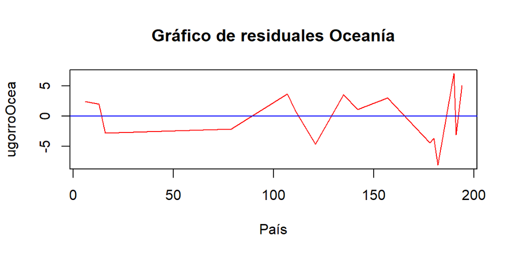

```r
k<-5
n2 = sum(datosCrecimientoOceania$Index)
ygorroOcea<-RegAlmostOcea$fitted.values
ugorroOcea<-RegAlmostOcea$residuals
sigmaOcea<-sum(ugorroOcea^2)/(n2-k-1)

plot(datosCrecimientoOceania$Index,ugorroOcea,type="l",
     col="red",
     main="Gráfico de residuales Oceanía",
     xlab = "País")
abline(h=0, col="blue")
```

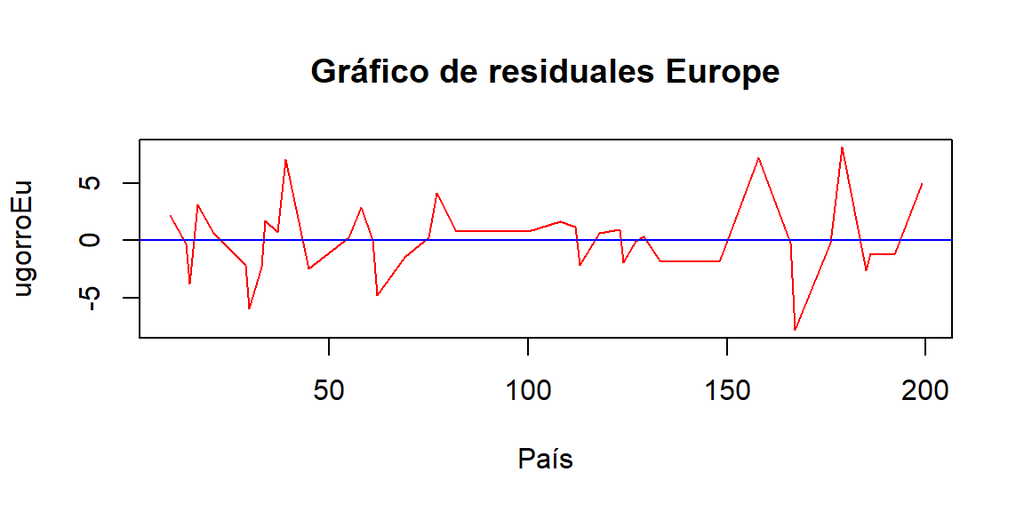

```r
k<-5
nEurope = sum(datosCrecimientoEuropa$Index)
ygorroEu<-RegAlmostEu$fitted.values
ugorroEu<-RegAlmostEu$residuals
sigmaEu<-sum(ugorroEu^2)/(nEurope-k-1)

plot(datosCrecimientoEuropa$Index,ugorroEu,type="l",
     col="red",
     main="Gráfico de residuales Europe",
     xlab = "País")
abline(h=0, col="blue")
```

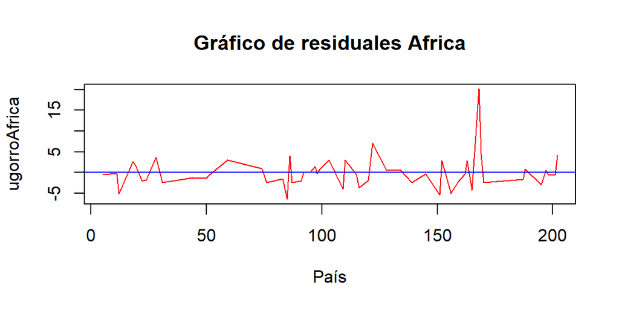

```r
k<-5
nAfrica = sum(datosCrecimientoAfrica$Index)
ygorroAfrica<-RegAlmostAfri$fitted.values
ugorroAfrica<-RegAlmostAfri$residuals
sigmaAfrica<-sum(ugorroAfrica^2)/(nAfrica-k-1)

plot(datosCrecimientoAfrica$Index,ugorroAfrica,type="l",
     col="red",
     main="Gráfico de residuales Africa",
     xlab = "País")
abline(h=0, col="blue")
```

## Corrección 4. NetMigr Dicotómica

Por lo anterior, concluimos que realizar un modelo para cada región no es conveniente y en su lugar, nos dispusimos a hacer una regresión dicotómica, en la que tomamos a la migración neta como variable categórica. Antes de continuar es importante mencionar que la migración neta se define como número de inmigrantes menos número de emigrantes. Así, si la migración neta de un país es negativa, la observación se codifica como 1 y si es positiva como 0.

```r
(dico1<-(NetMigr<0)*1)
```

```
##   [1] 1 1 1 1 0 1 1 1 1 0 1 0 1 0 0 1 0 1 1 1 0 0 1 1 0 1 0 0 0 0 1 0 0 1 0 1 0
##  [38] 0 0 1 0 1 1 1 0 0 1 1 1 1 1 1 1 1 0 0 1 0 0 0 0 1 1 1 0 0 0 0 0 1 0 0 0 0
##  [75] 1 1 1 0 0 1 1 1 0 1 1 1 0 1 0 0 1 0 0 1 1 1 1 1 1 1 0 0 0 0 1 1 0 0 1 1 0
## [112] 0 0 1 0 1 0 1 1 1 1 0 1 1 1 0 1 1 1 1 1 0 0 1 0 1 1 1 0 0 1 1 0 1 1 0 0 0
## [149] 1 1 1 1 0 1 1 1 0 1 0 0 1 1 0 1 0 0 1 1 1 1 1 1 1 0 1 1 1 1 0 0 0 1 1 0 1
## [186] 1 1 1 0 1 0 0 1 1 1 1 1 1 0 1 1
```

```r
dico1
```

```
##   [1] 1 1 1 1 0 1 1 1 1 0 1 0 1 0 0 1 0 1 1 1 0 0 1 1 0 1 0 0 0 0 1 0 0 1 0 1 0
##  [38] 0 0 1 0 1 1 1 0 0 1 1 1 1 1 1 1 1 0 0 1 0 0 0 0 1 1 1 0 0 0 0 0 1 0 0 0 0
##  [75] 1 1 1 0 0 1 1 1 0 1 1 1 0 1 0 0 1 0 0 1 1 1 1 1 1 1 0 0 0 0 1 1 0 0 1 1 0
## [112] 0 0 1 0 1 0 1 1 1 1 0 1 1 1 0 1 1 1 1 1 0 0 1 0 1 1 1 0 0 1 1 0 1 1 0 0 0
## [149] 1 1 1 1 0 1 1 1 0 1 0 0 1 1 0 1 0 0 1 1 1 1 1 1 1 0 1 1 1 1 0 0 0 1 1 0 1
## [186] 1 1 1 0 1 0 0 1 1 1 1 1 1 0 1 1
```

```r
regDic <- lm (GDPGrowth.~MobileSubs.100+UrbanPopGrowth.+FertRate+NetMigr+MortRateU5+dico1, data=datosCrecimiento2021)

stargazer(regDic,type="text")
```

```
##
## ===============================================
##                         Dependent variable:
##                     ---------------------------
##                             GDPGrowth.
## -----------------------------------------------
## MobileSubs.100               0.036***
##                               (0.013)
##
## UrbanPopGrowth.              1.086***
##                               (0.399)
##
## FertRate                     -1.458**
##                               (0.738)
##
## NetMigr                       0.00001
##                              (0.00001)
##
## MortRateU5                    -0.006
##                               (0.029)
##
## dico1                         -0.324
##                               (0.999)
##
## Constant                       3.348
##                               (2.261)
##
## -----------------------------------------------
## Observations                    201
## R2                             0.133
## Adjusted R2                    0.106
## Residual Std. Error      5.963 (df = 194)
## F Statistic           4.960*** (df = 6; 194)
## ===============================================
## Note:               *p<0.1; **p<0.05; ***p<0.01
```

## Corrección 5. Múltiples dicotómicas

Finalmente, desarrollamos una última regresión dicotómica en la que controlamos por región. En especial, elegimos a África como control y observamos el efecto individual de cada continente sobre el crecimiento económico.

```r
res <- model.matrix(~Region, data = datosCrecimiento2021)
```

```r
regDic2 <- lm (GDPGrowth.~MobileSubs.100+UrbanPopGrowth.+FertRate+NetMigr+MortRateU5+res, data=datosCrecimiento2021)

stargazer(regDic2,type="text")
```

```
##
## ===============================================
##                         Dependent variable:
##                     ---------------------------
##                             GDPGrowth.
## -----------------------------------------------
## MobileSubs.100                0.028**
##                               (0.014)
##
## UrbanPopGrowth.               0.994**
##                               (0.404)
##
## FertRate                      -1.361*
##                               (0.783)
##
## NetMigr                       0.00001
##                              (0.00000)
##
## MortRateU5                    -0.028
##                               (0.030)
##
## res(Intercept)
##
##
## resRegionAmericas             -0.414
##                               (1.729)
##
## resRegionAsia                 -2.316
##                               (1.549)
##
## resRegionEurope               -1.090
##                               (1.884)
##
## resRegionOceania             -5.392***
##                               (1.982)
##
## Constant                      5.803*
##                               (3.357)
##
## -----------------------------------------------
## Observations                    201
## R2                             0.181
## Adjusted R2                    0.143
## Residual Std. Error      5.839 (df = 191)
## F Statistic           4.706*** (df = 9; 191)
## ===============================================
## Note:               *p<0.1; **p<0.05; ***p<0.01
```

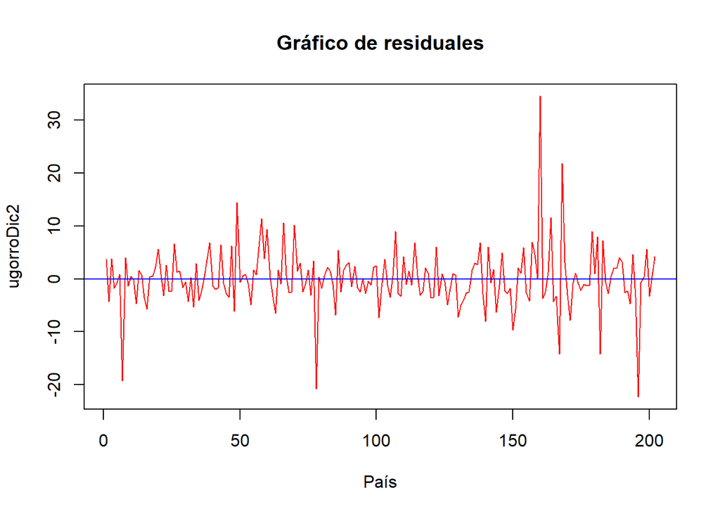

```r
k<-6
ygorroDic2<-regDic2$fitted.values
ugorroDic2<-regDic2$residuals
sigma2C<-sum(ugorro2C^2)/(n-k-1)

plot(datosCrecimiento2021$Index,ugorroDic2,type="l",
     col="red",
     main="Gráfico de residuales",
     xlab = "País")
abline(h=0, col="blue")
```

Hagamos por último las pruebas de supuestos:

```r
modelo<-regDic2
jarque.bera.test(modelo$residuals)
```

```
##
##  Jarque Bera Test
##
## data:  modelo$residuals
## X-squared = 675.54, df = 2, p-value < 2.2e-16
```

```r
#vif(modelo)
bptest(modelo)
```

```
##
##  studentized Breusch-Pagan test
##
## data:  modelo
## BP = 10.348, df = 9, p-value = 0.3231
```

```r
white(modelo,interactions = TRUE)
```

```
## # A tibble: 1 × 5
##   statistic p.value parameter method       alternative
##       <dbl>   <dbl>     <dbl> <chr>        <chr>
## 1      38.6   0.944        54 White's Test greater
```

```r
dwtest(modelo)
```

```
##
##  Durbin-Watson test
##
## data:  modelo
## DW = 2.2255, p-value = 0.762
## alternative hypothesis: true autocorrelation is greater than 0
```

```r
bgtest(modelo)
```

```
##
##  Breusch-Godfrey test for serial correlation of order up to 1
##
## data:  modelo
## LM test = 2.7749, df = 1, p-value = 0.09575
```

```r
resettest(modelo, power=2, type="fitted")
```

```
##
##  RESET test
##
## data:  modelo
## RESET = 0.48986, df1 = 1, df2 = 189, p-value = 0.4849
```

- **Prueba Jarque Bera:** El valor p continúa es menor que el nivel de significancia. Por ello, nuestro término estocástico no se distribuye de manera normal.
- **Prueba Breush Pagan y Godfrey:** En esta prueba el valor p es igual a 0.3231 y por lo tanto, es mayor que el nivel de significancia. Entonces, no hay heterocedasticidad en el modelo.
- **Prueba Durbin-Watson:** El valor p es igual a 0.762 y , por ende, es mayor que nuestro nivel de significancia 0.05. Entonces, nuestro modelo no presenta autocorrelación de primer orden.
- **Prueba de Breusch y Godfrey:** El valor p es igual a 0.09575 y en consecuencia, mayor a nuestro nivel de significancia. Cabe mencionar que en este modelo, la diferencia entre el valor p y el nivel de significancia es la más grande que hemos encontrado. Y en consecuencia, nuestro modelo no presenta autocorrelación de orden superior.
- **Prueba de especificación:** El valor p es mayor que el nivel de significancia, ya que es igual a 0.4849. Y de esta manera, el modelo está bien especificado.
- **Prueba de White:** En este caso el p- value confirma que el modelo no tiene un problema de Heteroscedasticidad.

# Conclusiones

Ahora bien, nuestro modelo aún presenta multicolinealidad; sin embargo, no cuenta con la presencia de la heterocedasticidad ni de la autocorrelación. La variable dicotómica que está controlada por la región, o bien el continente, a la que pertenecían los países si aumentó el R² ajustado. Como ya se mencionó, estos resultados no nos convencieron, ya que el continente de Oceanía presenta solo dieciséis observaciones y este es el coeficiente significativo de la nueva regresión que incluya a la dicotómica por continente.

Asimismo, este modelo presentaba cuatro nuevas regresoras del continente asiático, americano, europeo y de Oceanía. No obstante, la única variable significativa era la de este último continente. Por otro lado, suponemos que no logramos corregir el problema de la multicolinealidad debido a la tendencia común de nuestros datos. Nuestras variables presentaban alta colinealidad entre ellas, como fue en el caso de la tasa de fertilidad, esperanza de vida al nacer y la tasa de fertilidad adolescente. Por ello, decidimos eliminar a estas dos últimas variables.

Además, suponemos que el eliminar variables, como la tasa de fertilidad adolescente y la esperanza de vida al nacer, y la observación del país de Cuba no afectó a la especificación del modelo. La prueba de la especificación de la regresión no tuvo ningún problema.

Nos parece importante mencionar que el proceso para llegar a este modelo incluyó no solo eliminación, sino la elaboración de distintas pruebas que nos permitieron tomar estas decisiones. Para la eliminación de Cuba observamos el histograma y el diagrama de dispersión, los cuales indican la presencia de datos atípicos. Para eliminar variables consideramos que tuvieran correlaciones altas y poca significancia. Elaboramos múltiples modelos ascendentes para comparar la significancia y la aportación de cada una de las regresoras en el modelo y en el R². Claramente nuestro mayor problema está enfocado en la multicolinealidad. A pesar de agrupar a los 201 países en sus continentes, no todos los coeficientes mostraron ser significativos.

Nuestro último modelo, el cual incluye a la variable dicotómica de las diferentes regiones, demuestra que la migración neta y la tasa de mortalidad de niños menores a cinco años no son significativas para el crecimiento económico. Es decir, las variaciones del crecimiento del PIB no son explicadas por la diferencia entre el número de inmigrantes y emigrantes ni por la tasa de mortalidad de niños menores a cinco años. Por otro lado, las variaciones del término dependiente sí son explicadas por la tasa de fertilidad, la tasa de suscripciones a servicios de telefonía y el crecimiento de la población urbana.

Ahora bien, otra de las razones por las que podríamos estar obteniendo estos datos es por la pandemia del COVID-19. La causa muestral de la multicolinealidad nos indica que algunas variables pueden presentar alta correlación en ciertos intervalos o periodos de tiempo. Recordemos que diversas economías se estaban recuperando del confinamiento o incluso algunas aún seguían tomando ciertas medidas sanitarias que afectaron a algunas industrias.

La realidad es que los resultados de nuestro modelo nos sorprendieron. No esperábamos que la migración neta no fuera influyente en el crecimiento económico. Sin embargo, el contexto que envuelve al año 2021 puede influir en estas conclusiones a las que llegó la regresión. Pero el hecho de que una tasa de mortalidad no haya afectado al crecimiento del PIB en un periodo en el que exactamente apareció una enfermedad que mató a millones de personas captó nuestra atención. Esto podría ser debido a que la tasa de mortalidad es de infantes y no de personas de la tercera edad, el cual fue un grupo altamente afectado por la pandemia.

En miras al futuro, creemos que una continuación de este proyecto vale la pena en el contexto de un trabajo de investigación más robusto, como una tesis de licenciatura, en el que en lugar de ocupar la tasa de crecimiento como dependiente, sea sustituida por el residuo de Solow. Al hacer esto, esperaríamos un mejor desempeño del R<sup>2</sup> ajustado; no obstante, eso queda fuera del alcance de este análisis de variables alternativas de crecimiento.